# Valsamo_analysis

Theron Palmer

8/26/2021

# Load in the necessary libraries

```r
library(readxl)
library(ggplot2)
library(DT)
library(dplyr)
library(stringr)
library(rjson)
library(ComplexHeatmap)
library(GO.db)
library(KEGGREST)
# library(KEGG.db)
library(fgsea)
library(org.Hs.eg.db)
library(ggpubr)
library(DESeq2)
library(ggrepel)
library(ggprism)
library(rstatix)
mod_path <- function(path){ # requires path to be pulled from external mounted through wsl
  str_replace_all(path,"/mnt/f","F:")
}
```

# Exploring the sample metadata via the study manifest

## finding samples that did not get aligned on JHPCE for some reason

```r
manifest <- read_excel(mod_path("/mnt/f/Valsamo/manifest.xlsx"))
files_to_remove <- c("hg19MTERCC-ensembl75-genes-Q21777-Plate-1-E06_L65",
"hg19MTERCC-ensembl75-genes-Q21777-Plate-1-F12_L1.D707_508",
"hg19MTERCC-ensembl75-genes-Q23152+B4+H2+AG710464_L1.D705")
manifest <- manifest %>% dplyr::filter(!(Sample %in% files_to_remove))
manifest$Sample <- str_replace_all(manifest$Sample,"hg19MTERCC-ensembl75-genes-","")
fastq_files <- read.table(mod_path("/mnt/f/Valsamo/fastq_files.txt"))
SJ_files <- read.table(mod_path("/mnt/f/Valsamo/SJ_files.txt"))
SJ_files$sample_name <- vapply(SJ_files$V1,function(file){
  str_remove(file,"SJ.out.tab")
},character(1))
fastq_files$sample_name <- vapply(fastq_files$V1,function(file){
  str_remove(file,"_1.clipped.fastq.gz")
},character(1))
```

```r
missing_files <- data.frame(sprintf(mod_path("/dcs04/fertig/data/theron/share/%s",fastq_files[which(!(fastq_files$sample_name %in% SJ_files$sample_name)),"V1"])))
write.table(missing_files,file=mod_path("/mnt/f/Valsamo/missing_fasta.txt"),
            quote=F, col.names = F, row.names = F, sep = "\t")
```

## Looking at response rates across treatment group

RESIST 1.1 Progression Terms form: https://project.eortc.org/recist/wp-content/uploads/sites/4/2015/03/RECISTGuidelines.pdf

CR = Complete Response  
PD = Progressive Disease  
PR = Partial Response  
SD = Stable Disease  
NE = ?

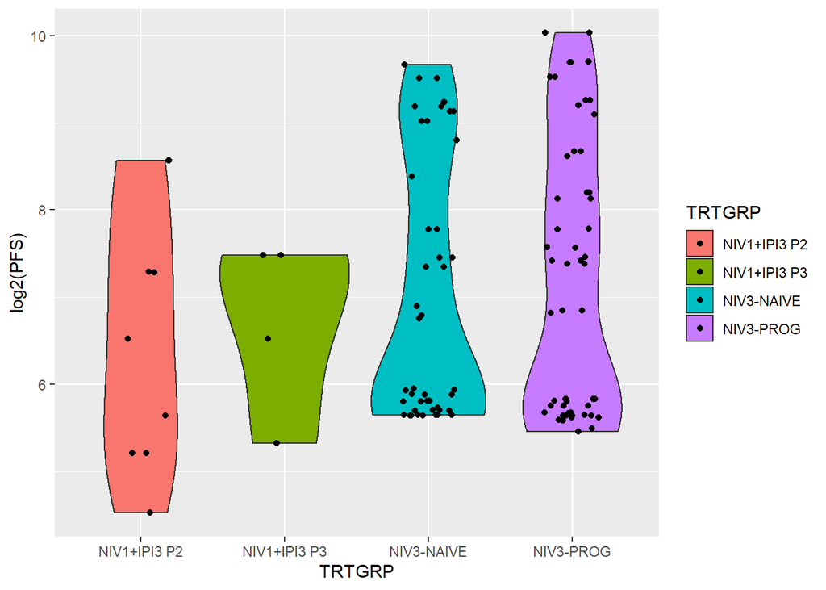

```r
ggplot(manifest,aes(x=TRTGRP,y=log2(PFS),fill=TRTGRP))+geom_violin()+geom_point(position = position_jitter(seed = 1, width = 0.2))
```

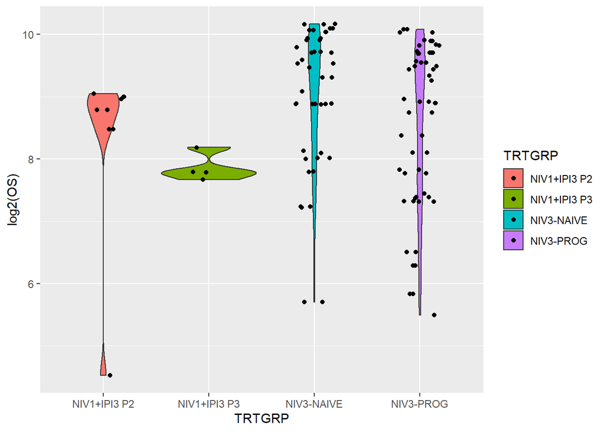

```r
ggplot(manifest,aes(x=TRTGRP,y=log2(OS),fill=TRTGRP))+geom_violin()+geom_point(position = position_jitter(seed = 1, width = 0.2))
```

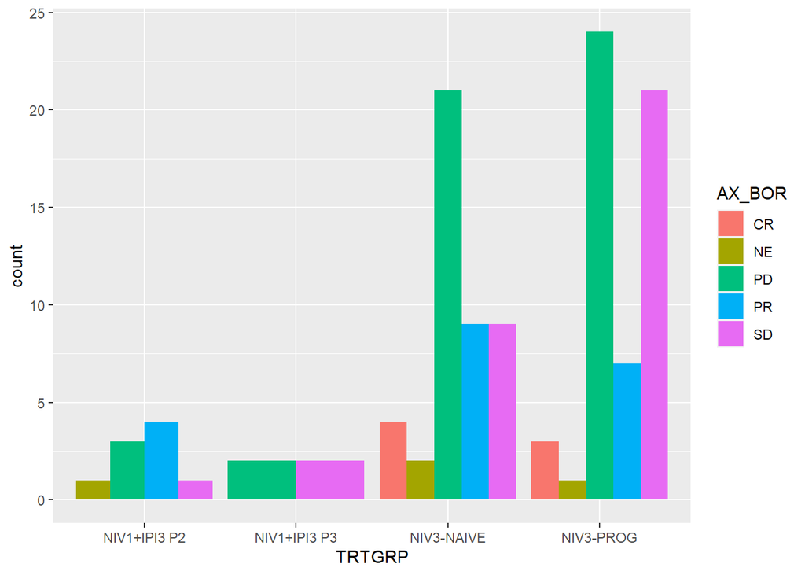

```r
ggplot(manifest,aes(x=TRTGRP,fill=AX_BOR))+geom_bar(position='dodge')
```

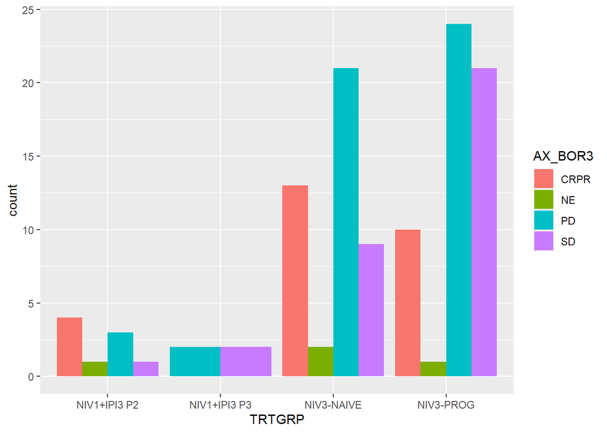

```r
ggplot(manifest,aes(x=TRTGRP,fill=AX_BOR3))+geom_bar(position='dodge')
```

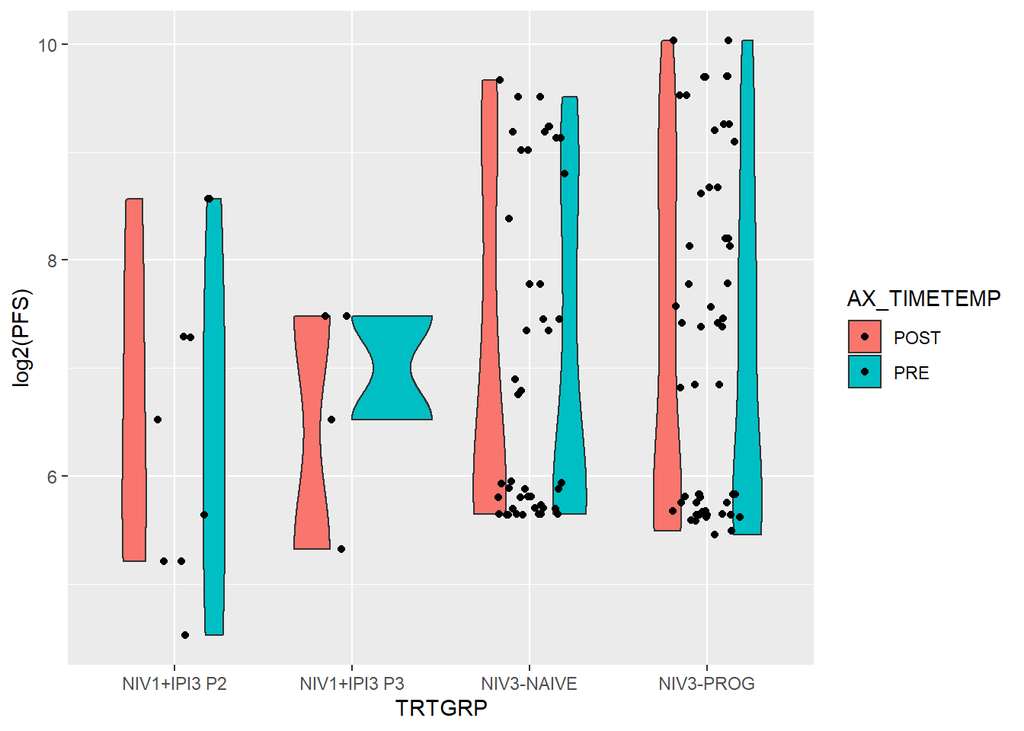

```r
ggplot(manifest,aes(x=TRTGRP,y=log2(PFS),fill=AX_TIMETEMP))+geom_violin()+geom_point(position = position_jitter(seed = 1, width = 0.2))
```

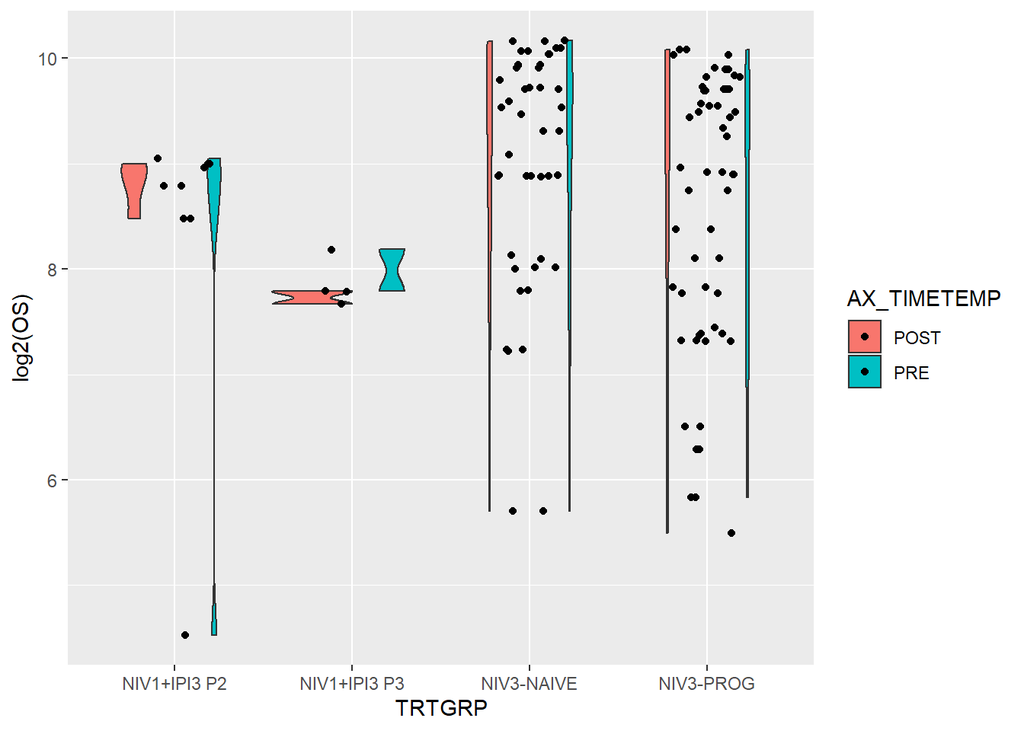

```r
ggplot(manifest,aes(x=TRTGRP,y=log2(OS),fill=AX_TIMETEMP))+geom_violin()+geom_point(position = position_jitter(seed = 1, width = 0.2))
```

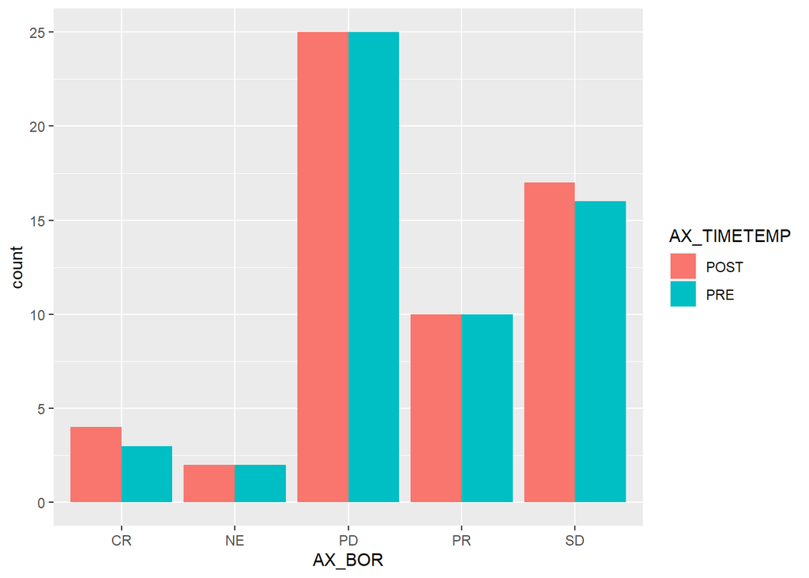

```r
ggplot(manifest,aes(x=AX_BOR,fill=AX_TIMETEMP))+geom_bar(position='dodge')
```

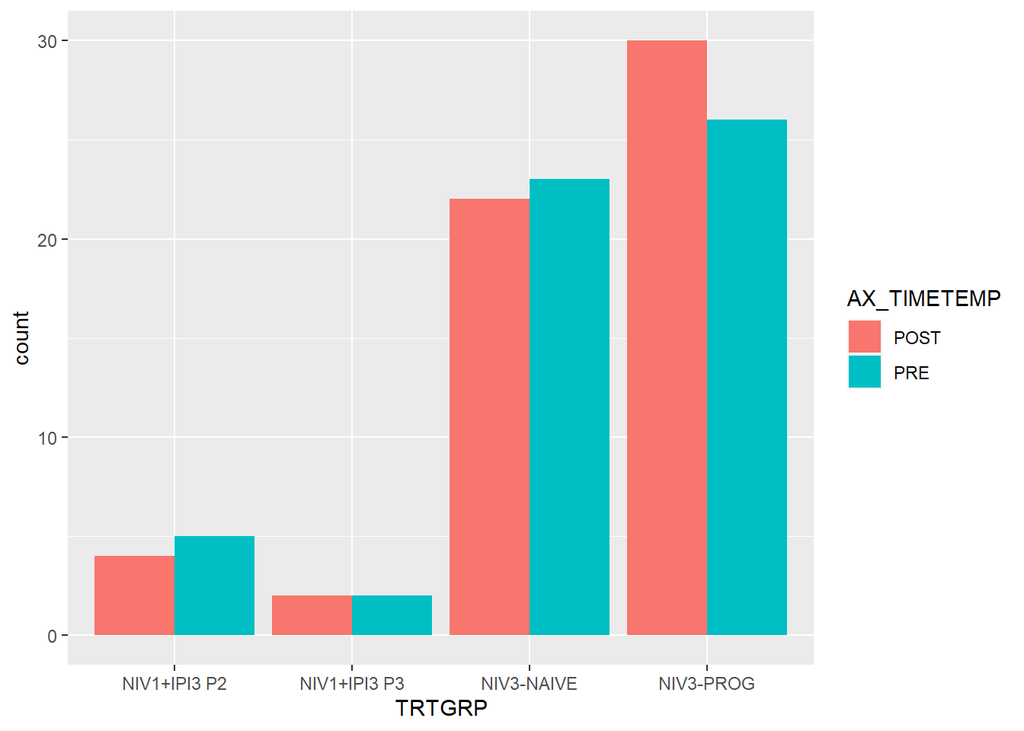

```r
ggplot(manifest,aes(x=TRTGRP,fill=AX_TIMETEMP))+geom_bar(position='dodge')
```

```r
datatable(data.frame(table(manifest$AX_TIMETEMP)))
```

|  | Var1 | Freq |
| --- | --- | --- |
| 1 | POST | 58 |
| 2 | PRE | 56 |

## Leafcutter Analysis Preparation before treatment

Comparisons: a) NIV3.NAIVE(PR) vs PD b) NIV3.NAIVE(CR) vs PD c) NIV3.NAIVE(SD) vs PD d) NIV3.NAIVE(NE) vs PD d) NIV3.PROG(PR) vs PD e) NIV3.PROG(CR) vs PD f) NIV3.PROG(SD) vs PD g) NIV3.PROG(SD) vs PD h) NIV1.IPI3(PR) vs PD  
i) NIV1.IPI3(SD) vs PD  
j) NIV1.IPI3(NE) vs PD k) PD vs RESP

# Forming groups_file.txt and junc_file.txt for each comparison before treatment

```r
NIV3_NAIVE <- manifest[which(manifest$TRTGRP == "NIV3-NAIVE" & manifest$AX_TIMETEMP=="PRE"),]
NIV3_PROG <- manifest[which(manifest$TRTGRP == "NIV3-PROG" & manifest$AX_TIMETEMP=="PRE"),]
NIV1_IPI3 <- manifest[which(manifest$TRTGRP %in% c("NIV1+IPI3 P2","NIV1+IPI3 P3") & manifest$AX_TIMETEMP=="PRE"),]
PD <- c(NIV3_NAIVE$Sample[NIV3_NAIVE$AX_BOR=="PD"],NIV3_PROG$Sample[NIV3_PROG$AX_BOR=="PD"],NIV1_IPI3$Sample[NIV1_IPI3$AX_BOR=="PD"])
RESP <- c(NIV3_NAIVE$Sample[NIV3_NAIVE$AX_BOR!="PD" & NIV3_NAIVE$AX_BOR!="NE"],
          NIV3_PROG$Sample[NIV3_PROG$AX_BOR!="PD" & NIV3_PROG$AX_BOR!="NE"],
          NIV1_IPI3$Sample[NIV1_IPI3$AX_BOR!="PD" & NIV1_IPI3$AX_BOR!="NE"])
groups_and_junc_dir <- mod_path("/mnt/f/Valsamo/leafcutter_prep/run_12072021")
JHPCE_dir <- "/dcs04/fertig/data/theron/share/juncs"
comparisons <- list()
state <- "PRE"
```

## NIV3.NAIVE(PR) vs PD

```r
tar<-"PR"
comp<-"PD"
tar_samp<-"NIV3_NAIVE"
comp_samp<-"PD"
comparison <- sprintf("%s_%s_%s_%s",tar_samp,comp_samp,tar,comp)
targets<-NIV3_NAIVE$Sample[NIV3_NAIVE$AX_BOR == tar]
comparators<-PD
a<-list()
a[["targets"]] <- targets
a[["comparators"]] <- comparators


for (target in targets){
  target_junc_file <- sprintf("%s/%s_juncs_%s_%s.txt",groups_and_junc_dir,target,comparison,state)
  file_contents <- sprintf("%s.filt.junc",c(target,comparators))
  file_contents <- data.frame(file_contents)
  write.table(file_contents,target_junc_file,
            sep="\t",
            quote=F,
            col.names=F,
            row.names=F)
}
comparisons[[sprintf("%s_%s",comparison,state)]] <- a
```

## NIV3.NAIVE(CR) vs PD

```r
tar<-"CR"
comp<-"PD"
tar_samp<-"NIV3_NAIVE"
comp_samp<-"PD"
comparison <- sprintf("%s_%s_%s_%s",tar_samp,comp_samp,tar,comp)
targets<-NIV3_NAIVE$Sample[NIV3_NAIVE$AX_BOR == tar]
comparators<-PD
a<-list()
a[["targets"]] <- targets
a[["comparators"]] <- comparators

for (target in targets){
  target_junc_file <- sprintf("%s/%s_juncs_%s_%s.txt",groups_and_junc_dir,target,comparison,state)
  file_contents <- sprintf("%s.filt.junc",c(target,comparators))
  file_contents <- data.frame(file_contents)
  write.table(file_contents,target_junc_file,
            sep="\t",
            quote=F,
            col.names=F,
            row.names=F)
}
comparisons[[sprintf("%s_%s",comparison,state)]] <- a
```

## NIV3.NAIVE(SD) vs PD

```r
tar<-"SD"
comp<-"PD"
tar_samp<-"NIV3_NAIVE"
comp_samp<-"PD"
comparison <- sprintf("%s_%s_%s_%s",tar_samp,comp_samp,tar,comp)
targets<-NIV3_NAIVE$Sample[NIV3_NAIVE$AX_BOR == tar]
comparators<-PD
a<-list()
a[["targets"]] <- targets
a[["comparators"]] <- comparators

for (target in targets){
  target_junc_file <- sprintf("%s/%s_juncs_%s_%s.txt",groups_and_junc_dir,target,comparison,state)
  file_contents <- sprintf("%s.filt.junc",c(target,comparators))
  file_contents <- data.frame(file_contents)
  write.table(file_contents,target_junc_file,
            sep="\t",
            quote=F,
            col.names=F,
            row.names=F)
}
comparisons[[sprintf("%s_%s",comparison,state)]] <- a
```

## NIV3.NAIVE(NE) vs PD

```r
tar<-"NE"
comp<-"PD"
tar_samp<-"NIV3_NAIVE"
comp_samp<-"PD"
comparison <- sprintf("%s_%s_%s_%s",tar_samp,comp_samp,tar,comp)
targets<-NIV3_NAIVE$Sample[NIV3_NAIVE$AX_BOR == tar]
comparators<-PD
a<-list()
a[["targets"]] <- targets
a[["comparators"]] <- comparators


for (target in targets){
  target_junc_file <- sprintf("%s/%s_juncs_%s_%s.txt",groups_and_junc_dir,target,comparison,state)
  file_contents <- sprintf("%s.filt.junc",c(target,comparators))
  file_contents <- data.frame(file_contents)
  write.table(file_contents,target_junc_file,
            sep="\t",
            quote=F,
            col.names=F,
            row.names=F)
}
comparisons[[sprintf("%s_%s",comparison,state)]] <- a
```

## NIV3.PROG(PR) vs PD

```r
tar<-"PR"
comp<-"PD"
tar_samp <- "NIV3_PROG"
comp_samp<-"PD"
comparison <- sprintf("%s_%s_%s_%s",tar_samp,comp_samp,tar,comp)
targets<-NIV3_PROG$Sample[NIV3_PROG$AX_BOR == tar]
comparators<-PD
a<-list()
a[["targets"]] <- targets
a[["comparators"]] <- comparators

for (target in targets){
  target_junc_file <- sprintf("%s/%s_juncs_%s_%s.txt",groups_and_junc_dir,target,comparison,state)
  file_contents <- sprintf("%s.filt.junc",c(target,comparators))
  file_contents <- data.frame(file_contents)
  write.table(file_contents,target_junc_file,
            sep="\t",
            quote=F,
            col.names=F,
            row.names=F)
}
comparisons[[sprintf("%s_%s",comparison,state)]] <- a
```

## NIV3.PROG(CR) vs PD

```r
tar<-"CR"
comp<-"PD"
tar_samp <- "NIV3_PROG"
comp_samp<-"PD"
comparison <- sprintf("%s_%s_%s_%s",tar_samp,comp_samp,tar,comp)
targets<-NIV3_PROG$Sample[NIV3_PROG$AX_BOR == tar]
comparators<-PD
a<-list()
a[["targets"]] <- targets
a[["comparators"]] <- comparators

for (target in targets){
  target_junc_file <- sprintf("%s/%s_juncs_%s_%s.txt",groups_and_junc_dir,target,comparison,state)
  file_contents <- sprintf("%s.filt.junc",c(target,comparators))
  file_contents <- data.frame(file_contents)
  write.table(file_contents,target_junc_file,
            sep="\t",
            quote=F,
            col.names=F,
            row.names=F)
}
comparisons[[sprintf("%s_%s",comparison,state)]] <- a
```

## NIV3.PROG(SD) vs PD

```r
tar<-"SD"
comp<-"PD"
tar_samp <- "NIV3_PROG"
comp_samp<-"PD"
comparison <- sprintf("%s_%s_%s_%s",tar_samp,comp_samp,tar,comp)
targets<-NIV3_PROG$Sample[NIV3_PROG$AX_BOR == tar]
comparators<-PD
a<-list()
a[["targets"]] <- targets
a[["comparators"]] <- comparators

for (target in targets){
  target_junc_file <- sprintf("%s/%s_juncs_%s_%s.txt",groups_and_junc_dir,target,comparison,state)
  file_contents <- sprintf("%s.filt.junc",c(target,comparators))
  file_contents <- data.frame(file_contents)
  write.table(file_contents,target_junc_file,
            sep="\t",
            quote=F,
            col.names=F,
            row.names=F)
}
comparisons[[sprintf("%s_%s",comparison,state)]] <- a
```

## NIV3.PROG(NE) vs PD

```r
tar<-"NE"
comp<-"PD"
tar_samp <- "NIV3_PROG"
comp_samp<-"PD"
comparison <- sprintf("%s_%s_%s_%s",tar_samp,comp_samp,tar,comp)
targets<-NIV3_PROG$Sample[NIV3_PROG$AX_BOR == tar]
comparators<-PD
a<-list()
a[["targets"]] <- targets
a[["comparators"]] <- comparators

for (target in targets){
  target_junc_file <- sprintf("%s/%s_juncs_%s_%s.txt",groups_and_junc_dir,target,comparison,state)
  file_contents <- sprintf("%s.filt.junc",c(target,comparators))
  file_contents <- data.frame(file_contents)
  write.table(file_contents,target_junc_file,
            sep="\t",
            quote=F,
            col.names=F,
            row.names=F)
}
comparisons[[sprintf("%s_%s",comparison,state)]] <- a
```

## NIV1.IPI3(PR) vs PD

```r
tar<-"PR"
comp<-"PD"
tar_samp <- "NIV1_IPI3"
comp_samp<-"PD"
comparison <- sprintf("%s_%s_%s_%s",tar_samp,comp_samp,tar,comp)
targets<-NIV1_IPI3$Sample[NIV1_IPI3$AX_BOR == tar]
comparators<-PD
a<-list()
a[["targets"]] <- targets
a[["comparators"]] <- comparators

for (target in targets){
  target_junc_file <- sprintf("%s/%s_juncs_%s_%s.txt",groups_and_junc_dir,target,comparison,state)
  file_contents <- sprintf("%s.filt.junc",c(target,comparators))
  file_contents <- data.frame(file_contents)
  write.table(file_contents,target_junc_file,
            sep="\t",
            quote=F,
            col.names=F,
            row.names=F)
}
comparisons[[sprintf("%s_%s",comparison,state)]] <- a
```

## NIV1.IPI3(SD) vs PD

```r
tar<-"SD"
comp<-"PD"
tar_samp <- "NIV1_IPI3"
comp_samp<-"PD"
comparison <- sprintf("%s_%s_%s_%s",tar_samp,comp_samp,tar,comp)
targets<-NIV1_IPI3$Sample[NIV1_IPI3$AX_BOR == tar]
comparators<-PD
a<-list()
a[["targets"]] <- targets
a[["comparators"]] <- comparators

for (target in targets){
  target_junc_file <- sprintf("%s/%s_juncs_%s_%s.txt",groups_and_junc_dir,target,comparison,state)
  file_contents <- sprintf("%s.filt.junc",c(target,comparators))
  file_contents <- data.frame(file_contents)
  write.table(file_contents,target_junc_file,
            sep="\t",
            quote=F,
            col.names=F,
            row.names=F)
}
comparisons[[sprintf("%s_%s",comparison,state)]] <- a
```

## NIV1.IPI3(NE) vs PD

```r
tar<-"NE"
comp<-"PD"
tar_samp <- "NIV1_IPI3"
comp_samp<-"PD"
comparison <- sprintf("%s_%s_%s_%s",tar_samp,comp_samp,tar,comp)
targets<-NIV1_IPI3$Sample[NIV1_IPI3$AX_BOR == tar]
comparators<-PD
a<-list()
a[["targets"]] <- targets
a[["comparators"]] <- comparators

for (target in targets){
  target_junc_file <- sprintf("%s/%s_juncs_%s_%s.txt",groups_and_junc_dir,target,comparison,state)
  file_contents <- sprintf("%s.filt.junc",c(target,comparators))
  file_contents <- data.frame(file_contents)
  write.table(file_contents,target_junc_file,
            sep="\t",
            quote=F,
            col.names=F,
            row.names=F)
}
comparisons[[sprintf("%s_%s",comparison,state)]] <- a
```

## PD vs RESP

```r
tar<-"PD"
comp<-"RESP"
tar_samp <- "PD"
comp_samp<-"RESP"
comparison <- sprintf("%s_%s_%s_%s",tar_samp,comp_samp,tar,comp)
targets<-PD
comparators<-RESP
a<-list()
a[["targets"]] <- targets
a[["comparators"]] <- comparators

for (target in targets){
  target_junc_file <- sprintf("%s/%s_juncs_%s_%s.txt",groups_and_junc_dir,target,comparison,state)
  file_contents <- sprintf("%s.filt.junc",c(target,comparators))
  file_contents <- data.frame(file_contents)
  write.table(file_contents,target_junc_file,
            sep="\t",
            quote=F,
            col.names=F,
            row.names=F)
}
comparisons[[sprintf("%s_%s",comparison,state)]] <- a
```

## Leafcutter Analysis Preparation after treatment

Comparisons: a) NIV3.NAIVE(PR) vs PD b) NIV3.NAIVE(CR) vs PD c) NIV3.NAIVE(SD) vs PD d) NIV3.NAIVE(NE) vs PD d) NIV3.PROG(PR) vs PD e) NIV3.PROG(CR) vs PD f) NIV3.PROG(SD) vs PD g) NIV3.PROG(SD) vs PD h) NIV1.IPI3(PR) vs PD  
i) NIV1.IPI3(SD) vs PD  
j) NIV1.IPI3(NE) vs PD k) PD vs RESP

# Forming groups_file.txt and junc_file.txt for each comparison after treatment

```r
NIV3_NAIVE <- manifest[which(manifest$TRTGRP == "NIV3-NAIVE" & manifest$AX_TIMETEMP=="POST"),]
NIV3_PROG <- manifest[which(manifest$TRTGRP == "NIV3-PROG" & manifest$AX_TIMETEMP=="POST"),]
NIV1_IPI3 <- manifest[which(manifest$TRTGRP %in% c("NIV1+IPI3 P2","NIV1+IPI3 P3") & manifest$AX_TIMETEMP=="POST"),]
PD <- c(NIV3_NAIVE$Sample[NIV3_NAIVE$AX_BOR=="PD"],NIV3_PROG$Sample[NIV3_PROG$AX_BOR=="PD"],NIV1_IPI3$Sample[NIV1_IPI3$AX_BOR=="PD"])
RESP <- c(NIV3_NAIVE$Sample[NIV3_NAIVE$AX_BOR!="PD" & NIV3_NAIVE$AX_BOR!="NE"],
          NIV3_PROG$Sample[NIV3_PROG$AX_BOR!="PD" & NIV3_PROG$AX_BOR!="NE"],
          NIV1_IPI3$Sample[NIV1_IPI3$AX_BOR!="PD" & NIV1_IPI3$AX_BOR!="NE"])
groups_and_junc_dir <- mod_path("/mnt/f/Valsamo/leafcutter_prep/run_12072021")
JHPCE_dir <- "/dcs04/fertig/data/theron/share/juncs"
state <- "POST"
```

## NIV3.NAIVE(PR) vs PD

```r
tar<-"PR"
comp<-"PD"
tar_samp<-"NIV3_NAIVE"
comp_samp<-"PD"
comparison <- sprintf("%s_%s_%s_%s",tar_samp,comp_samp,tar,comp)
targets<-NIV3_NAIVE$Sample[NIV3_NAIVE$AX_BOR == tar]
comparators<-PD
a<-list()
a[["targets"]] <- targets
a[["comparators"]] <- comparators

for (target in targets){
  target_junc_file <- sprintf("%s/%s_juncs_%s_%s.txt",groups_and_junc_dir,target,comparison,state)
  file_contents <- sprintf("%s.filt.junc",c(target,comparators))
  file_contents <- data.frame(file_contents)
  write.table(file_contents,target_junc_file,
            sep="\t",
            quote=F,
            col.names=F,
            row.names=F)
}
comparisons[[sprintf("%s_%s",comparison,state)]] <- a
```

## NIV3.NAIVE(CR) vs PD

```r
tar<-"CR"
comp<-"PD"
tar_samp<-"NIV3_NAIVE"
comp_samp<-"PD"
comparison <- sprintf("%s_%s_%s_%s",tar_samp,comp_samp,tar,comp)
targets<-NIV3_NAIVE$Sample[NIV3_NAIVE$AX_BOR == tar]
comparators<-PD
a<-list()
a[["targets"]] <- targets
a[["comparators"]] <- comparators

for (target in targets){
  target_junc_file <- sprintf("%s/%s_juncs_%s_%s.txt",groups_and_junc_dir,target,comparison,state)
  file_contents <- sprintf("%s.filt.junc",c(target,comparators))
  file_contents <- data.frame(file_contents)
  write.table(file_contents,target_junc_file,
            sep="\t",
            quote=F,
            col.names=F,
            row.names=F)
}
comparisons[[sprintf("%s_%s",comparison,state)]] <- a
```

## NIV3.NAIVE(SD) vs PD

```r
tar<-"SD"
comp<-"PD"
tar_samp<-"NIV3_NAIVE"
comp_samp<-"PD"
comparison <- sprintf("%s_%s_%s_%s",tar_samp,comp_samp,tar,comp)
targets<-NIV3_NAIVE$Sample[NIV3_NAIVE$AX_BOR == tar]
comparators<-PD
a<-list()
a[["targets"]] <- targets
a[["comparators"]] <- comparators

for (target in targets){
  target_junc_file <- sprintf("%s/%s_juncs_%s_%s.txt",groups_and_junc_dir,target,comparison,state)
  file_contents <- sprintf("%s.filt.junc",c(target,comparators))
  file_contents <- data.frame(file_contents)
  write.table(file_contents,target_junc_file,
            sep="\t",
            quote=F,
            col.names=F,
            row.names=F)
}
comparisons[[sprintf("%s_%s",comparison,state)]] <- a
```

## NIV3.NAIVE(NE) vs PD

```r
tar<-"NE"
comp<-"PD"
tar_samp<-"NIV3_NAIVE"
comp_samp<-"PD"
comparison <- sprintf("%s_%s_%s_%s",tar_samp,comp_samp,tar,comp)
targets<-NIV3_NAIVE$Sample[NIV3_NAIVE$AX_BOR == tar]
comparators<-PD
a<-list()
a[["targets"]] <- targets
a[["comparators"]] <- comparators

for (target in targets){
  target_junc_file <- sprintf("%s/%s_juncs_%s_%s.txt",groups_and_junc_dir,target,comparison,state)
  file_contents <- sprintf("%s.filt.junc",c(target,comparators))
  file_contents <- data.frame(file_contents)
  write.table(file_contents,target_junc_file,
            sep="\t",
            quote=F,
            col.names=F,
            row.names=F)
}
comparisons[[sprintf("%s_%s",comparison,state)]] <- a
```

## NIV3.PROG(PR) vs PD

```r
tar<-"PR"
comp<-"PD"
tar_samp <- "NIV3_PROG"
comp_samp<-"PD"
comparison <- sprintf("%s_%s_%s_%s",tar_samp,comp_samp,tar,comp)
targets<-NIV3_PROG$Sample[NIV3_PROG$AX_BOR == tar]
comparators<-PD
a<-list()
a[["targets"]] <- targets
a[["comparators"]] <- comparators

for (target in targets){
  target_junc_file <- sprintf("%s/%s_juncs_%s_%s.txt",groups_and_junc_dir,target,comparison,state)
  file_contents <- sprintf("%s.filt.junc",c(target,comparators))
  file_contents <- data.frame(file_contents)
  write.table(file_contents,target_junc_file,
            sep="\t",
            quote=F,
            col.names=F,
            row.names=F)
}
comparisons[[sprintf("%s_%s",comparison,state)]] <- a
```

## NIV3.PROG(CR) vs PD

```r
tar<-"CR"
comp<-"PD"
tar_samp <- "NIV3_PROG"
comp_samp<-"PD"
comparison <- sprintf("%s_%s_%s_%s",tar_samp,comp_samp,tar,comp)
targets<-NIV3_PROG$Sample[NIV3_PROG$AX_BOR == tar]
comparators<-PD
a<-list()
a[["targets"]] <- targets
a[["comparators"]] <- comparators

for (target in targets){
  target_junc_file <- sprintf("%s/%s_juncs_%s_%s.txt",groups_and_junc_dir,target,comparison,state)
  file_contents <- sprintf("%s.filt.junc",c(target,comparators))
  file_contents <- data.frame(file_contents)
  write.table(file_contents,target_junc_file,
            sep="\t",
            quote=F,
            col.names=F,
            row.names=F)
}
comparisons[[sprintf("%s_%s",comparison,state)]] <- a
```

## NIV3.PROG(SD) vs PD

```r
tar<-"SD"
comp<-"PD"
tar_samp <- "NIV3_PROG"
comp_samp<-"PD"
comparison <- sprintf("%s_%s_%s_%s",tar_samp,comp_samp,tar,comp)
targets<-NIV3_PROG$Sample[NIV3_PROG$AX_BOR == tar]
comparators<-PD
a<-list()
a[["targets"]] <- targets
a[["comparators"]] <- comparators

for (target in targets){
  target_junc_file <- sprintf("%s/%s_juncs_%s_%s.txt",groups_and_junc_dir,target,comparison,state)
  file_contents <- sprintf("%s.filt.junc",c(target,comparators))
  file_contents <- data.frame(file_contents)
  write.table(file_contents,target_junc_file,
            sep="\t",
            quote=F,
            col.names=F,
            row.names=F)
}
comparisons[[sprintf("%s_%s",comparison,state)]] <- a
```

## NIV3.PROG(NE) vs PD

```r
tar<-"NE"
comp<-"PD"
tar_samp <- "NIV3_PROG"
comp_samp<-"PD"
comparison <- sprintf("%s_%s_%s_%s",tar_samp,comp_samp,tar,comp)
targets<-NIV3_PROG$Sample[NIV3_PROG$AX_BOR == tar]
comparators<-PD
a<-list()
a[["targets"]] <- targets
a[["comparators"]] <- comparators

for (target in targets){
  target_junc_file <- sprintf("%s/%s_juncs_%s_%s.txt",groups_and_junc_dir,target,comparison,state)
  file_contents <- sprintf("%s.filt.junc",c(target,comparators))
  file_contents <- data.frame(file_contents)
  write.table(file_contents,target_junc_file,
            sep="\t",
            quote=F,
            col.names=F,
            row.names=F)
}
comparisons[[sprintf("%s_%s",comparison,state)]] <- a
```

## NIV1.IPI3(PR) vs PD

```r
tar<-"PR"
comp<-"PD"
tar_samp <- "NIV1_IPI3"
comp_samp<-"PD"
comparison <- sprintf("%s_%s_%s_%s",tar_samp,comp_samp,tar,comp)
targets<-NIV1_IPI3$Sample[NIV1_IPI3$AX_BOR == tar]
comparators<-PD
a<-list()
a[["targets"]] <- targets
a[["comparators"]] <- comparators

for (target in targets){
  target_junc_file <- sprintf("%s/%s_juncs_%s_%s.txt",groups_and_junc_dir,target,comparison,state)
  file_contents <- sprintf("%s.filt.junc",c(target,comparators))
  file_contents <- data.frame(file_contents)
  write.table(file_contents,target_junc_file,
            sep="\t",
            quote=F,
            col.names=F,
            row.names=F)
}
comparisons[[sprintf("%s_%s",comparison,state)]] <- a
```

## NIV1.IPI3(SD) vs PD

```r
tar<-"SD"
comp<-"PD"
tar_samp <- "NIV1_IPI3"
comp_samp<-"PD"
comparison <- sprintf("%s_%s_%s_%s",tar_samp,comp_samp,tar,comp)
targets<-NIV1_IPI3$Sample[NIV1_IPI3$AX_BOR == tar]
comparators<-PD
a<-list()
a[["targets"]] <- targets
a[["comparators"]] <- comparators

for (target in targets){
  target_junc_file <- sprintf("%s/%s_juncs_%s_%s.txt",groups_and_junc_dir,target,comparison,state)
  file_contents <- sprintf("%s.filt.junc",c(target,comparators))
  file_contents <- data.frame(file_contents)
  write.table(file_contents,target_junc_file,
            sep="\t",
            quote=F,
            col.names=F,
            row.names=F)
}
comparisons[[sprintf("%s_%s",comparison,state)]] <- a
```

## NIV1.IPI3(NE) vs PD

```r
tar<-"NE"
comp<-"PD"
tar_samp <- "NIV1_IPI3"
comp_samp<-"PD"
comparison <- sprintf("%s_%s_%s_%s",tar_samp,comp_samp,tar,comp)
targets<-NIV1_IPI3$Sample[NIV1_IPI3$AX_BOR == tar]
comparators<-PD
a<-list()
a[["targets"]] <- targets
a[["comparators"]] <- comparators

for (target in targets){
  target_junc_file <- sprintf("%s/%s_juncs_%s_%s.txt",groups_and_junc_dir,target,comparison,state)
  file_contents <- sprintf("%s.filt.junc",c(target,comparators))
  file_contents <- data.frame(file_contents)
  write.table(file_contents,target_junc_file,
            sep="\t",
            quote=F,
            col.names=F,
            row.names=F)
}
comparisons[[sprintf("%s_%s",comparison,state)]] <- a
```

## PD vs RESP

```r
tar<-"PD"
comp<-"RESP"
tar_samp <- "PD"
comp_samp<-"RESP"
comparison <- sprintf("%s_%s_%s_%s",tar_samp,comp_samp,tar,comp)
targets<-PD
comparators<-RESP
a<-list()
a[["targets"]] <- targets
a[["comparators"]] <- comparators

for (target in targets){
  target_junc_file <- sprintf("%s/%s_juncs_%s_%s.txt",groups_and_junc_dir,target,comparison,state)
  file_contents <- sprintf("%s.filt.junc",c(target,comparators))
  file_contents <- data.frame(file_contents)
  write.table(file_contents,target_junc_file,
            sep="\t",
            quote=F,
            col.names=F,
            row.names=F)
}
comparisons[[sprintf("%s_%s",comparison,state)]] <- a

saveRDS(comparisons,file=mod_path("/mnt/f/Valsamo/analysis/leafcutterMD/run_12072021/comparisons.rds"))
comp_frame <- data.frame(names(comparisons))
write.table(comp_frame,
            file=mod_path("/mnt/f/Valsamo/analysis/leafcutterMD/run_12072021/comparisons.txt"),
            quote=F,
            sep="\t",
            col.names=F,
            row.names=F)
```

# Processing comparison juncs

```r
comparison_junctions <- list()
leafcutter_files <- read.table(mod_path("/mnt/f/Valsamo/analysis/leafcutterMD/run_12072021/filenames.txt"))
for (i in seq(nrow(leafcutter_files))){
  print(i)
  outlier_file <- leafcutter_files[i,]
  outlier_juncs <- read.table(outlier_file)
  outlier_junc_cols <- str_replace_all(colnames(outlier_juncs),".filt","")
  colnames(outlier_juncs) <- str_replace_all(outlier_junc_cols,"[-_+.]","_")
  file_split <- strsplit(outlier_file,"_juncs_")[[1]]
  sample <- basename(file_split[1])
  sample <- substr(sample,1,nchar(sample))
  sample<-str_replace_all(sample,"[-_+.]","_")
  arm_info <- strsplit(file_split[2],"_")[[1]]
  tar_samp <- sprintf("%s_%s",arm_info[1],arm_info[2])
  comp_samp <- arm_info[3]
  if (length(arm_info) == 6){
    tar_samp <- arm_info[1]
    comp_samp <- arm_info[2]
    tar<-arm_info[3]
    comp<-arm_info[4]
    time<-arm_info[5]
  } else {
    tar_samp <- sprintf("%s_%s",arm_info[1],arm_info[2])
    comp_samp <- arm_info[3]
    tar <- arm_info[4]
    comp <- arm_info[5]
    time <- arm_info[6]
  }
  comparison <- sprintf("%s_%s_%s_%s_%s",tar_samp,comp_samp,tar,comp,time)
  sig_juncs <- rownames(outlier_juncs)[as.numeric(outlier_juncs[,sample]) <=0.05]
  comparison_junctions[[comparison]] <- unique(c(comparison_junctions[[comparison]],sig_juncs))
}
```

```r
comparison_juncs_linear <- data.frame(t(vapply(unname(unlist(comparison_junctions)),function(junc){
  junc_vals<-strsplit(junc,":")[[1]]
  strand<-strsplit(junc_vals[4],"_")[[1]][3]
  c(junc_vals[1],junc_vals[2],junc_vals[3],strand)
},character(4))))
rownames(comparison_juncs_linear)<-seq(nrow(comparison_juncs_linear))
colnames(comparison_juncs_linear)<-c("chr","start","end","strand")
comparison_juncs_linear<-unique(comparison_juncs_linear)


iter<-1
total_juncs <- nrow(comparison_juncs_linear)
for (i in seq(1,total_juncs,5000)){
  if (i+4999 >= total_juncs){
    end = total_juncs
  } else {
    end = i+4999
  }
  comparison_juncs_small <- comparison_juncs_linear[seq(i,end),]
  saveRDS(comparison_juncs_small,
          sprintf(mod_path("/mnt/f/Valsamo/analysis/leafcutterMD/run_12072021/comparison_juncs_linear_%d.rds",iter)))
  iter<-iter+1
}


saveRDS(comparison_juncs_linear,file=mod_path("/mnt/f/Valsamo/analysis/leafcutterMD/run_12072021/comparison_juncs_linear.rds"))
saveRDS(comparison_junctions,file=mod_path("/mnt/f/Valsamo/analysis/leafcutterMD/run_12072021/comparison_juncs.rds"))
```

# Calculating junction usage and coding potential characteristics

# Processing the gene metric data

## Mean processing

```r
comparisons_file <- mod_path("/mnt/f/Valsamo/analysis/JHPCE/create_comparisons/comparisons.rds")
comparison_dat <- readRDS(comparisons_file)

gene_metric_files <- mod_path("/mnt/f/Valsamo/analysis/JHPCE/calc_gene_metric_out_cp/gene_metric_files_mean.txt")
gene_metric_comp<-read.table(gene_metric_files,header=F)
total_genes<-c()
all_comps <- list()
samples <- c()
comparisons <- c()
comp_genes <- list()
for (comp in gene_metric_comp$V1){
  comp_dir <- dirname(comp)
  comp_vals <- readRDS(mod_path(comp))
  comp <- str_replace(basename(comp),"_gene_metric_mean_len_norm.rds","")
  coding_potential_file <- sprintf("%s/%s_coding_potential_LGC.rds",comp_dir,comp)
  coding_potential_LGC <- readRDS(mod_path(coding_potential_file))
  HIGH_CP_GENES <- rownames(coding_potential_LGC)[coding_potential_LGC$coding_potential>0]
  comp_split <- strsplit(comp,"_")[[1]]
  targets <- comparison_dat[[comp]]$targets
  targets <- targets[which(targets %in% colnames(comp_vals))]
  comp_vals <- comp_vals[HIGH_CP_GENES,targets,drop=F]
  targets <-   sprintf("%s_%s",targets,comp_split[length(comp_split)])
  # print(comp)
  # print(targets)
  genes <- rownames(comp_vals)
  comp_genes[[comp]] <- unique(genes)
  total_genes<-unique(c(total_genes,genes))
  all_comps[[comp]] <- comp_vals
  samples <- c(samples,targets)
  comparisons <- c(comparisons,rep(comp,ncol(comp_vals)))
}
```

## Mean comparisons all pre-processing

```r
comp_vals_all <- data.frame(total_genes)
rownames(comp_vals_all)<-total_genes
for (comp in names(all_comps)){
  comp_vals <- all_comps[[comp]]
  comp_split <- strsplit(comp,"_")[[1]]
  comp_vals_all[rownames(comp_vals),sprintf("%s_%s",colnames(comp_vals),comp_split[length(comp_split)])]<-comp_vals
}
comp_vals_all <- comp_vals_all[,seq(2,ncol(comp_vals_all))]

col_data <- data.frame(samples,comparisons)
col_data$time <- vapply(col_data$comparisons,function(comp){
  a<-strsplit(comp,"_")[[1]]
  return(a[length(a)])
},character(1))
col_data$comp <- vapply(col_data$comparisons,function(comp_val){
  a<-str_split(comp_val,"_")[[1]]
  return(paste(a[seq(length(a)-1)],collapse="_"))
},character(1))
col_data$sample <- vapply(col_data$samples,function(samp){
  a<-str_split(samp,"_")[[1]]
  return(paste(a[seq(length(a)-1)],collapse="_"))
},character(1))
col_data$subj_id <- vapply(col_data$sample,function(samp){
  s<<-samp
  manifest$AX_USUBJID[manifest$Sample == samp]
},character(1))
col_data$response <- vapply(col_data$comp,function(comp){
  a<-str_split(comp,"_")[[1]]
  b<-a[length(a)-1]
  if (b %in% c("CR","PR")){
    b <- "CR_PR"
  }
  return(b)
},character(1))
col_data$comparator <- vapply(col_data$comp,function(comp){
  a<-str_split(comp,"_")[[1]]
  b<-a[length(a)]
  if (b %in% c("CR","PR")){
    b <- "CR_PR"
  }
  return(b)
},character(1))
col_data$PFS <- vapply(col_data$subj_id,function(subject){
  return(manifest$PFS[manifest$AX_USUBJID == subject][1])
},numeric(1))
col_data$OS <- vapply(col_data$subj_id,function(subject){
  return(manifest$OS[manifest$AX_USUBJID == subject][1])
},numeric(1))
col_data$treatment <- vapply(col_data$subj_id,function(subject){
  return(str_split(manifest$TRTGRP[manifest$AX_USUBJID == subject][1]," ")[[1]][1])
},character(1))
col_data <- col_data %>% dplyr::filter(col_data$samples %in% colnames(comp_vals_all))

comp_vals_all[is.na(comp_vals_all)]<-0
comp_vals_all <- comp_vals_all[apply(comp_vals_all,1,sd)!=0,]
# all(col_data$samples == colnames(comp_vals_all)) == TRUE

col_data <- col_data[order(col_data$comparisons),]
comp_vals_all <- comp_vals_all[,order(col_data$comparisons)]

PRE_cols <- which(str_detect(colnames(comp_vals_all),"PRE"))
POST_cols <- which(str_detect(colnames(comp_vals_all),"POST"))

comp_vals_PRE <- comp_vals_all[,PRE_cols]
col_data_PRE <- col_data[PRE_cols,]
PRE_cols <- which(col_data_PRE$response != "NE")
comp_vals_PRE <- comp_vals_PRE[,PRE_cols]
col_data_PRE <- col_data_PRE[PRE_cols,]

comp_vals_POST <- comp_vals_all[,POST_cols]
col_data_POST <- col_data[POST_cols,]
POST_cols <- which(col_data_POST$response != "NE")
comp_vals_POST <- comp_vals_POST[,POST_cols]
col_data_POST <- col_data_POST[POST_cols,]

color_vals <- c("red","green","blue","red","green","blue")
names(color_vals)<-c("CR_PR","SD","PD","NIV1+IPI3","NIV3-NAIVE","NIV3-PROG")
```

## Proprocessing junctions per comparison

```r
calc_mean_CP <- function(splice_dat,comp_str){
  juncs <- unique(splice_dat$juncs)
  a<-vapply(juncs,function(junc){
    mean(splice_dat[splice_dat$juncs==junc,"coding_potential_LGC"],na.rm=T)
  },numeric(1))
  junc_LGC <- data.frame(LGC = a)
  junc_LGC$comp <- comp_str
  return(junc_LGC)
}
calc_junc_types <- function(splice_dat,comp_str){
  junc_types <- data.frame(table(splice_dat$error))
  junc_types$comp <- comp_str
  total <- sum(junc_types$Freq)
  junc_types$Freq <- junc_types$Freq/total
  return(junc_types)
}

comparisons_file <- mod_path("/mnt/f/Valsamo/analysis/JHPCE/create_comparisons/comparisons.rds")
comparison_dat <- readRDS(comparisons_file)
splice_dat_files <-  read.table(mod_path("/mnt/f/Valsamo/analysis/JHPCE/create_comparisons_out_cp/filenames.txt"))


comparisons <- c()
for (val in seq(length(splice_dat_files$V1))){
  print(val)
  comp<-splice_dat_files$V1[val]
  splice_dat <- readRDS(mod_path(comp))
  comp_dir <- dirname(comp)
  splice_dat_comp <- readRDS(mod_path(comp))
  comp_str <- str_replace(basename(comp),"splice_dat_","")
  comp_str <- str_replace(basename(comp_str),".rds","")
  comparisons <- c(comparisons,comp_str)
  if (val == 1){
    splice_dat_CP_LGC <- calc_mean_CP(splice_dat_comp,comp_str)
    all_junc_types <- calc_junc_types(splice_dat_comp,comp_str)
  } else {
    splice_dat_CP_LGC <- rbind(splice_dat_CP_LGC,calc_mean_CP(splice_dat_comp,comp_str))
    all_junc_types <- rbind(all_junc_types,calc_junc_types(splice_dat_comp,comp_str))
  }
}
```

```
## [1] 1
## [1] 2
## [1] 3
## [1] 4
## [1] 5
## [1] 6
## [1] 7
## [1] 8
## [1] 9
## [1] 10
## [1] 11
## [1] 12
## [1] 13
## [1] 14
## [1] 15
## [1] 16
## [1] 17
## [1] 18
## [1] 19
## [1] 20
## [1] 21
## [1] 22
```

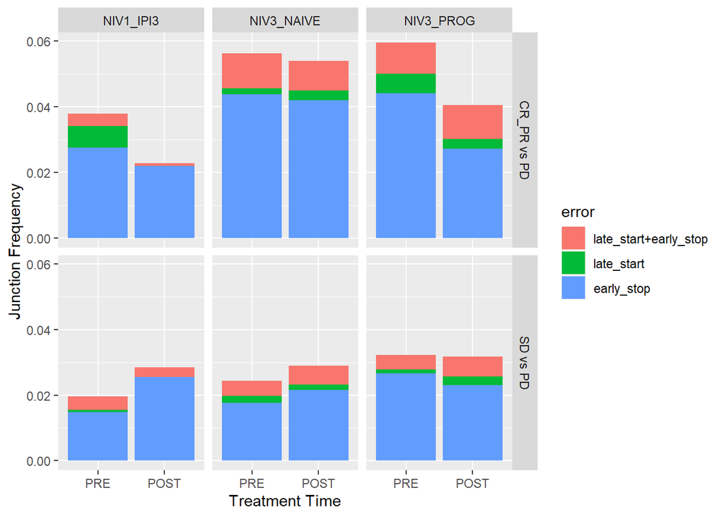

```r
times <- vapply(comparisons,function(comp){
  a<-strsplit(comp,"_")[[1]]
  return(a[length(a)])
},character(1))
comps <- vapply(comparisons,function(comp_val){
  a<-str_split(comp_val,"_")[[1]]
  return(paste(a[seq(length(a)-1)],collapse="_"))
},character(1))
responses <- vapply(comparisons,function(comp){
  a<-str_split(comp,"_")[[1]]
  b<-a[length(a)-2]
  if (b %in% c("CR","PR")){
    b <- "CR_PR"
  }
  return(b)
},character(1))
comparators <- vapply(comparisons,function(comp){
  a<-str_split(comp,"_")[[1]]
  b<-a[length(a)-1]
  if (b %in% c("CR","PR")){
    b <- "CR_PR"
  }
  return(b)
},character(1))
treatments <- vapply(comparisons,function(comp){
  a<-str_split(comp,"_")[[1]]
  b<-paste(a[seq(2)],collapse="_")
  return(b)
},character(1))
metadata <- data.frame(comp=comps,time=times,response=responses,comparator=comparators,treatment=treatments)
metadata$comparison <- sprintf("%s vs %s",metadata$response,metadata$comparator)
splice_dat_CP_LGC <- cbind(splice_dat_CP_LGC,metadata[splice_dat_CP_LGC$comp,seq(2,ncol(metadata))])
all_junc_types <- cbind(all_junc_types,metadata[all_junc_types$comp,seq(2,ncol(metadata))])

all_junc_types$time <- factor(all_junc_types$time,levels=c("PRE","POST"))
all_junc_types$error <- factor(vapply(all_junc_types$Var1,function(val){
  if (val == "start_not_beg"){
    return("late_start")
  } else if (val == "start_not_beg:stop_not_end"){
    return("late_start+early_stop")
  } else if (val == "stop_not_end"){
    return("early_stop")
  } else if (val=="tx"){
    return("tx")
  }
},character(1)),levels=c("late_start+early_stop","late_start","early_stop"))

all_junc_types_filt <- all_junc_types[all_junc_types$Var1!="tx",]
all_junc_types_filt$comparison <- sprintf("%s vs %s",all_junc_types_filt$response,all_junc_types_filt$comparator)
all_junc_types_filt_PD <- all_junc_types_filt[all_junc_types_filt$comparison == "PD vs RESP",]
all_junc_types_filt <- all_junc_types_filt[all_junc_types_filt$comparison != "NE vs PD" & all_junc_types_filt$comparison != "PD vs RESP",]

ggplot(all_junc_types_filt,aes(y=Freq,x=time,fill=error))+
  geom_bar(stat="identity")+facet_grid(comparison~treatment)+
  ylab("Junction Frequency")+
  xlab("Treatment Time")
```

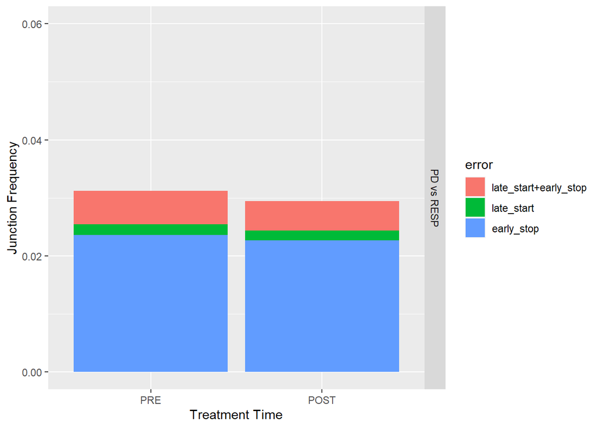

```r
ggplot(all_junc_types_filt_PD,aes(y=Freq,x=time,fill=error))+
  geom_bar(stat="identity")+facet_grid(comparison~.)+
  ylim(c(0,0.06))+
  ylab("Junction Frequency")+
  xlab("Treatment Time")
```

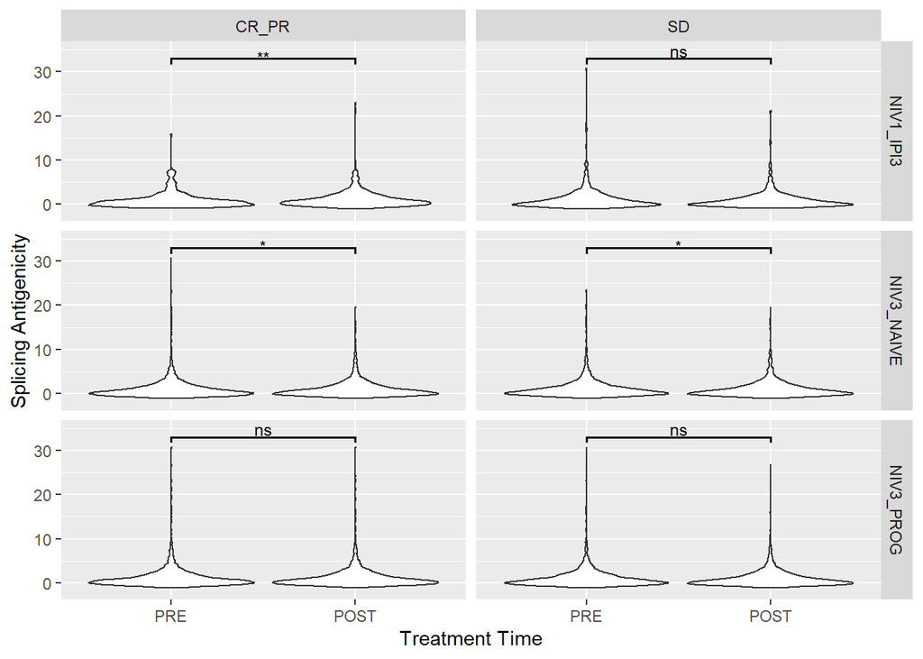

```r
splice_dat_CP_LGC_filt <- splice_dat_CP_LGC[splice_dat_CP_LGC$comparison != "NE vs PD",]
splice_dat_CP_LGC_filt$resp <- splice_dat_CP_LGC_filt$response
splice_dat_CP_LGC_filt_PD <- splice_dat_CP_LGC_filt[splice_dat_CP_LGC_filt$treatment == "PD_RESP",]
splice_dat_CP_LGC_filt <- splice_dat_CP_LGC_filt[splice_dat_CP_LGC_filt$treatment!="PD_RESP",]
splice_dat_CP_LGC_filt$time <- factor(splice_dat_CP_LGC_filt$time,levels=c("PRE","POST"))
wilcox_test_val_all <- compare_means(LGC ~ time, p.adjust.method = "BH", data=splice_dat_CP_LGC_filt,group.by = c("response","treatment"))
ggplot(splice_dat_CP_LGC_filt,aes(x=time,y=LGC))+
  geom_violin()+
  facet_grid(treatment~response)+
  add_pvalue(wilcox_test_val_all, label = "p.signif", remove.bracket = TRUE,y.position=33)+
  ylab("Splicing Antigenicity")+
  xlab("Treatment Time")+
  ylim(c(-2,35))
```

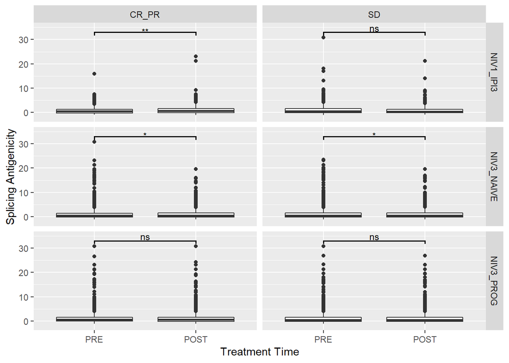

```r
ggplot(splice_dat_CP_LGC_filt,aes(x=time,y=LGC))+
  geom_boxplot()+
  facet_grid(treatment~response)+
  add_pvalue(wilcox_test_val_all, label = "p.signif", remove.bracket = TRUE,y.position=33)+
  ylab("Splicing Antigenicity")+
  xlab("Treatment Time")+
  ylim(c(-2,35))
```

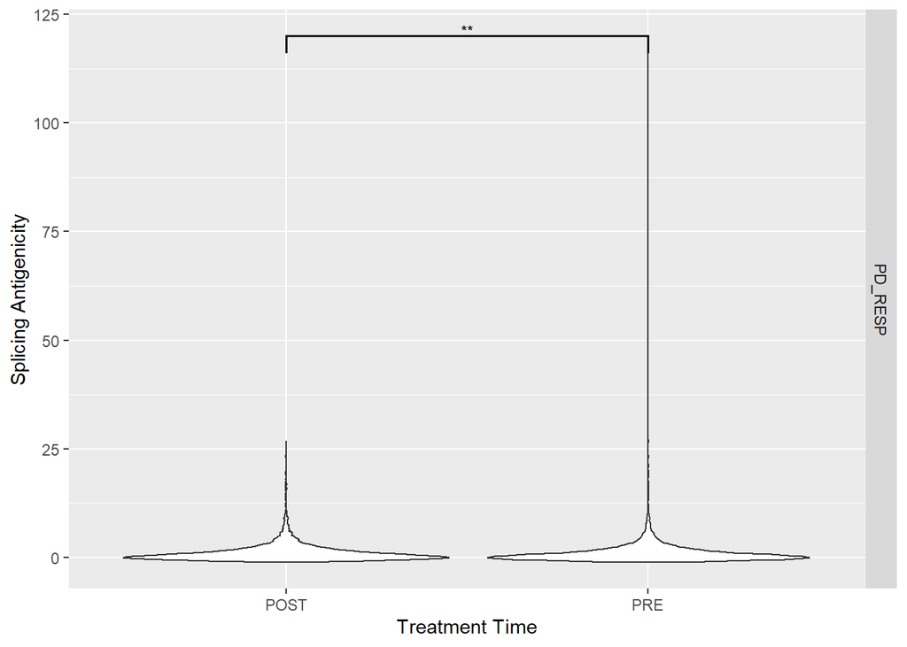

```r
wilcox_test_val_all <- compare_means(LGC ~ time, p.adjust.method = "BH", data=splice_dat_CP_LGC_filt_PD,group.by = c("response","treatment"))
ggplot(splice_dat_CP_LGC_filt_PD,aes(x=time,y=LGC))+
  geom_violin()+
  facet_grid(treatment~.)+
  add_pvalue(wilcox_test_val_all, label = "p.signif", remove.bracket = TRUE,y.position=120)+
  ylab("Splicing Antigenicity")+
  xlab("Treatment Time")
```

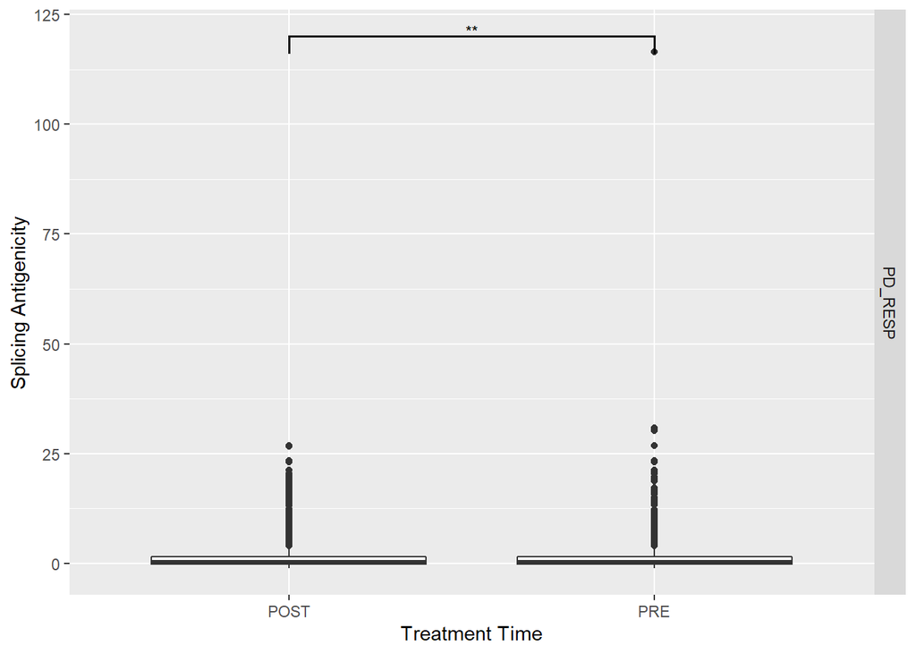

```r
ggplot(splice_dat_CP_LGC_filt_PD,aes(x=time,y=LGC))+
  geom_boxplot()+
  facet_grid(treatment~.)+
  add_pvalue(wilcox_test_val_all, label = "p.signif", remove.bracket = TRUE,y.position=120)+
  ylab("Splicing Antigenicity")+
  xlab("Treatment Time")
```

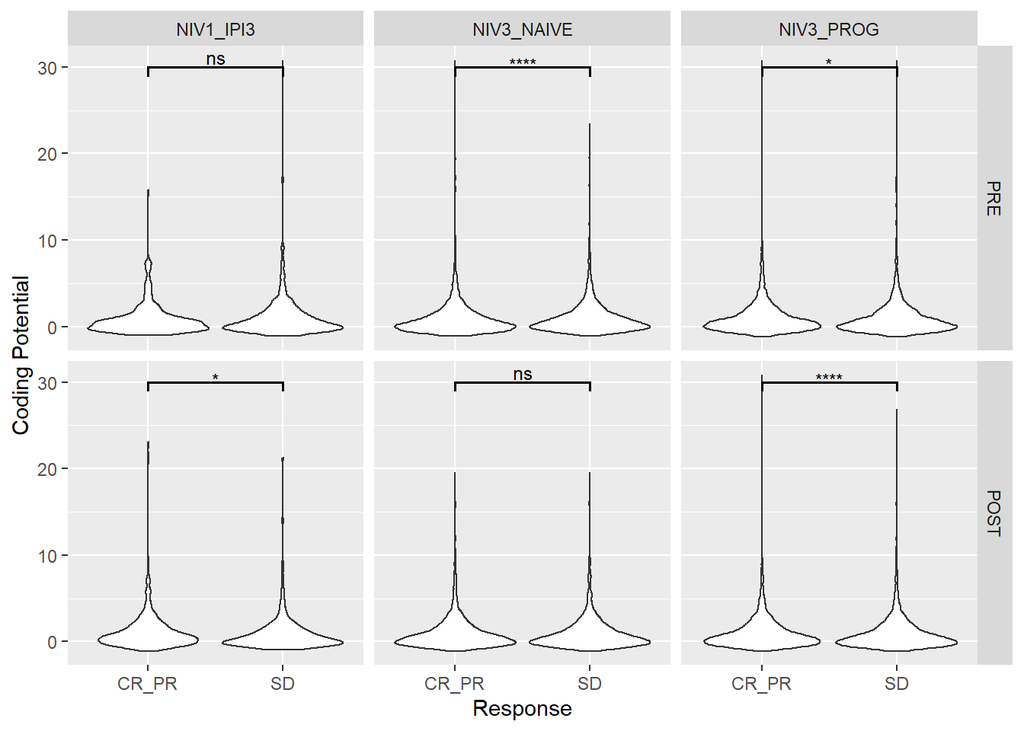

```r
splice_dat_CP_LGC_filt <- splice_dat_CP_LGC[splice_dat_CP_LGC$comparison != "NE vs PD",]
splice_dat_CP_LGC_filt$resp <- splice_dat_CP_LGC_filt$response
splice_dat_CP_LGC_filt_PD <- splice_dat_CP_LGC_filt[splice_dat_CP_LGC_filt$treatment == "PD_RESP",]
splice_dat_CP_LGC_filt <- splice_dat_CP_LGC_filt[splice_dat_CP_LGC_filt$treatment!="PD_RESP",]
splice_dat_CP_LGC_filt$time <- factor(splice_dat_CP_LGC_filt$time,levels=c("PRE","POST"))
wilcox_test_val_all <- compare_means(LGC ~ response, p.adjust.method = "BH", data=splice_dat_CP_LGC_filt,group.by = c("treatment","time"))
# wilcox_test_val_all$y.position <- c(35,33,31,35,33,31,35,33,31,35,33,31,35,33,31,35,33,3)
ggplot(splice_dat_CP_LGC_filt,aes(x=response,y=LGC))+
  geom_violin()+
  facet_grid(time~treatment)+
  add_pvalue(wilcox_test_val_all, label = "p.signif", remove.bracket = TRUE,y.position=30)+
  ylab("Coding Potential")+
  xlab("Response")
```

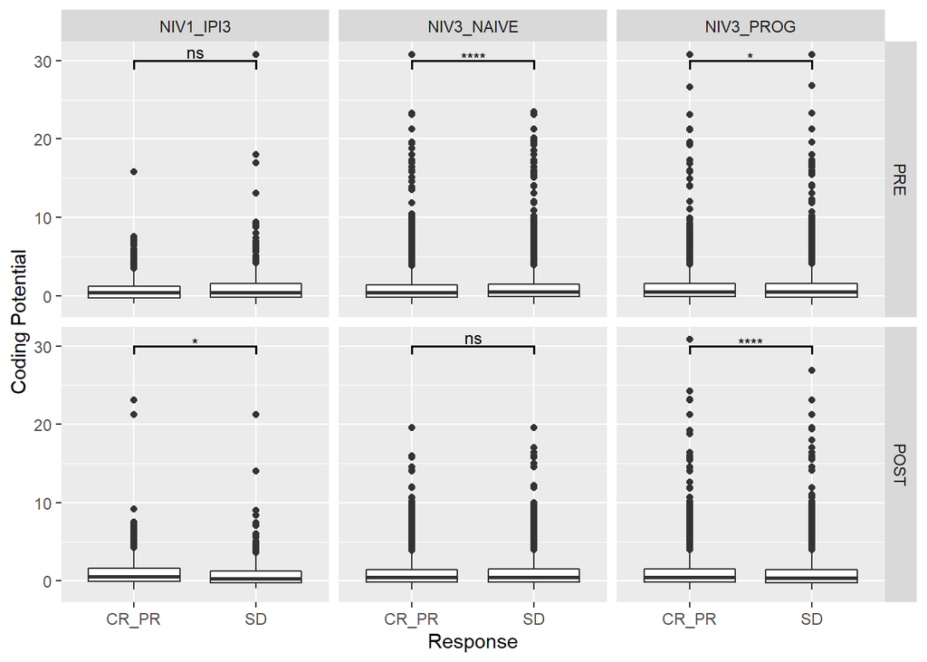

```r
ggplot(splice_dat_CP_LGC_filt,aes(x=response,y=LGC))+
  geom_boxplot()+
  facet_grid(time~treatment)+
  add_pvalue(wilcox_test_val_all, label = "p.signif", remove.bracket = TRUE,y.position=30)+
  ylab("Coding Potential")+
  xlab("Response")
```

### PRE Heatmap

[output not shown]

[output not shown]

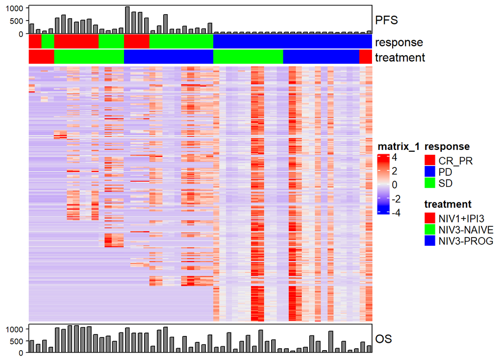

```r
comp_vals_PRE <- comp_vals_PRE[apply(comp_vals_PRE,1,sd)!=0,]
Heatmap(t(apply(as.matrix(comp_vals_PRE),1,scale)),
    top_annotation = HeatmapAnnotation(PFS=anno_barplot(col_data_PRE$PFS),
                                       response=col_data_PRE$response,
                                       treatment=col_data_PRE$treatment,
                                       col=list(response=c("CR_PR"="red","SD"="green","PD"="blue"),
                                                treatment=c("NIV1+IPI3"="red","NIV3-NAIVE"="green","NIV3-PROG"="blue"))),
    bottom_annotation = HeatmapAnnotation(OS=anno_barplot(col_data_PRE$OS)),
    show_row_names=F,
    show_column_names = F,
    cluster_rows=F,
    cluster_columns=F)
```

[output not shown]

[output not shown]

[output not shown]

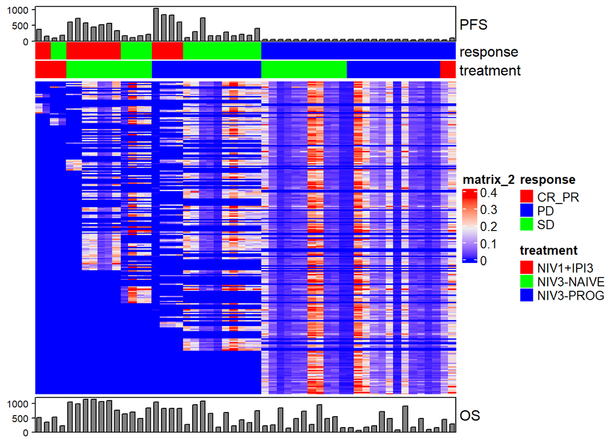

```r
Heatmap(comp_vals_PRE,
    top_annotation = HeatmapAnnotation(PFS=anno_barplot(col_data_PRE$PFS),
                                       response=col_data_PRE$response,
                                       treatment=col_data_PRE$treatment,
                                       col=list(response=c("CR_PR"="red","SD"="green","PD"="blue"),
                                                treatment=c("NIV1+IPI3"="red","NIV3-NAIVE"="green","NIV3-PROG"="blue"))),
    bottom_annotation = HeatmapAnnotation(OS=anno_barplot(col_data_PRE$OS)),
    show_row_names=F,
    show_column_names = F,
    cluster_rows=F,
    cluster_columns=F)
```

### POST Heatmap

[output not shown]

[output not shown]

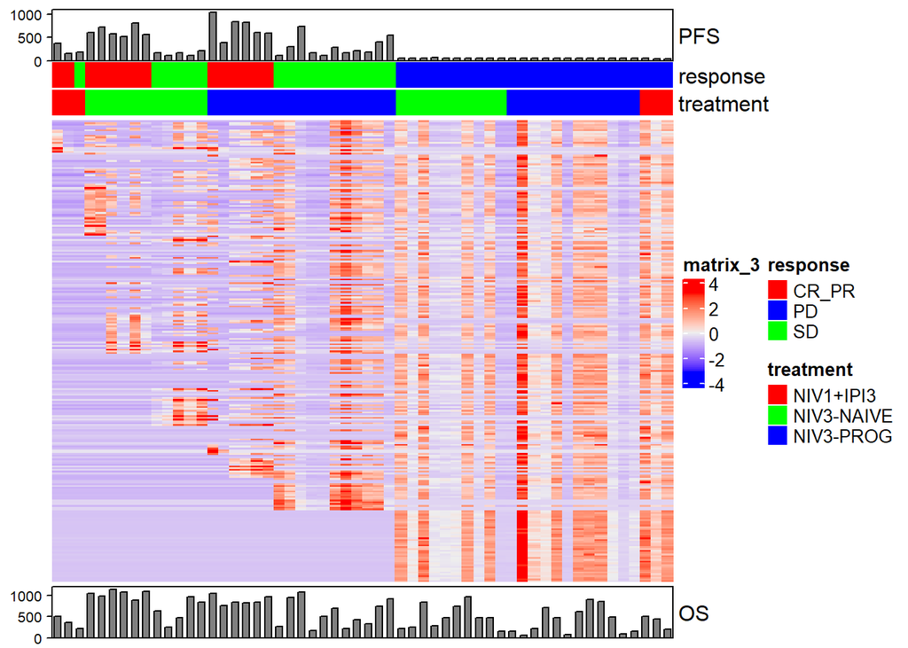

```r
comp_vals_POST <- comp_vals_POST[apply(comp_vals_POST,1,sd)!=0,]
Heatmap(t(apply(as.matrix(comp_vals_POST),1,scale)),
    top_annotation = HeatmapAnnotation(PFS=anno_barplot(col_data_POST$PFS),
                                       response=col_data_POST$response,
                                       treatment=col_data_POST$treatment,
                                       col=list(response=c("CR_PR"="red","SD"="green","PD"="blue"),
                                                treatment=c("NIV1+IPI3"="red","NIV3-NAIVE"="green","NIV3-PROG"="blue"))),
    bottom_annotation = HeatmapAnnotation(OS=anno_barplot(col_data_POST$OS)),
    show_row_names=F,
    show_column_names = F,
    cluster_rows=F,
    cluster_columns=F)
```

[output not shown]

[output not shown]

[output not shown]

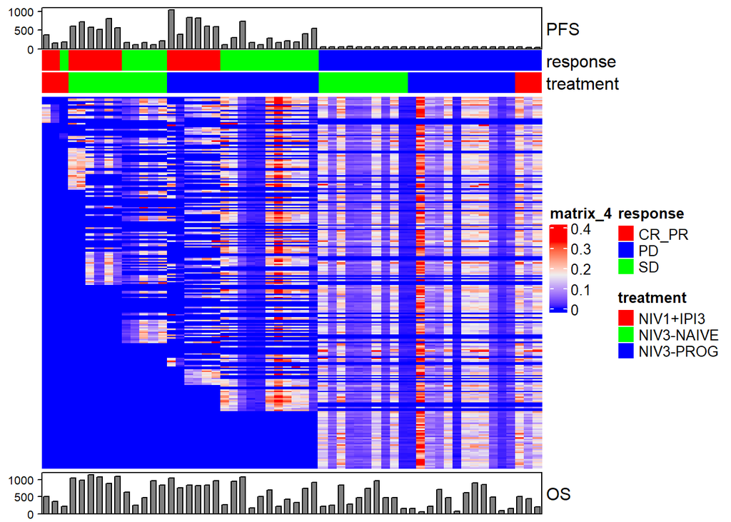

```r
Heatmap(comp_vals_POST,
    top_annotation = HeatmapAnnotation(PFS=anno_barplot(col_data_POST$PFS),
                                       response=col_data_POST$response,
                                       treatment=col_data_POST$treatment,
                                       col=list(response=c("CR_PR"="red","SD"="green","PD"="blue"),
                                                treatment=c("NIV1+IPI3"="red","NIV3-NAIVE"="green","NIV3-PROG"="blue"))),
    bottom_annotation = HeatmapAnnotation(OS=anno_barplot(col_data_POST$OS)),
    show_row_names=F,
    show_column_names = F,
    cluster_rows=F,
    cluster_columns=F)
```

### Pre average mean comparisons

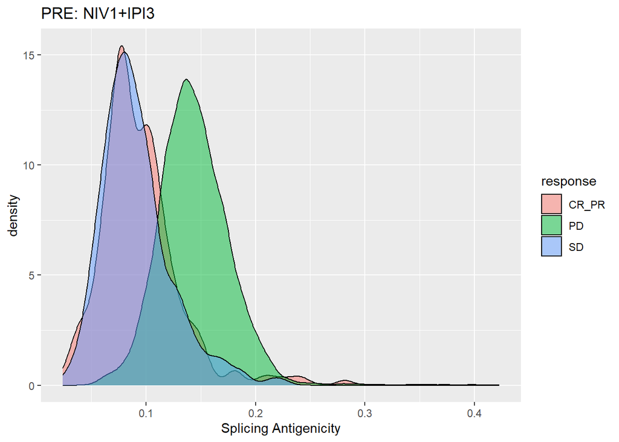

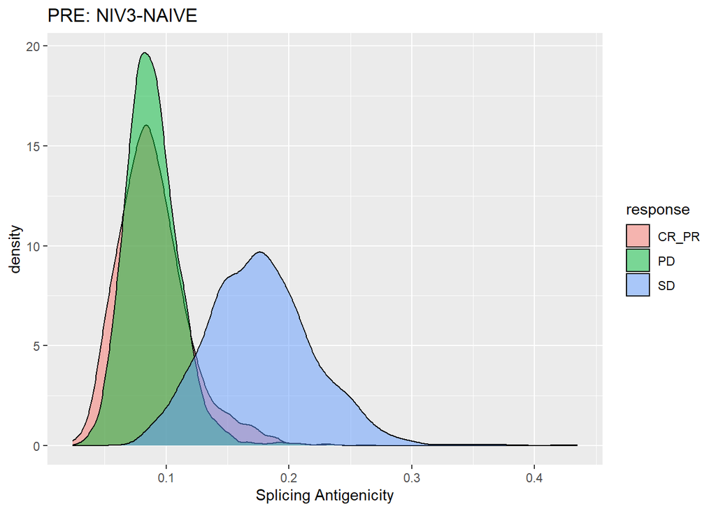

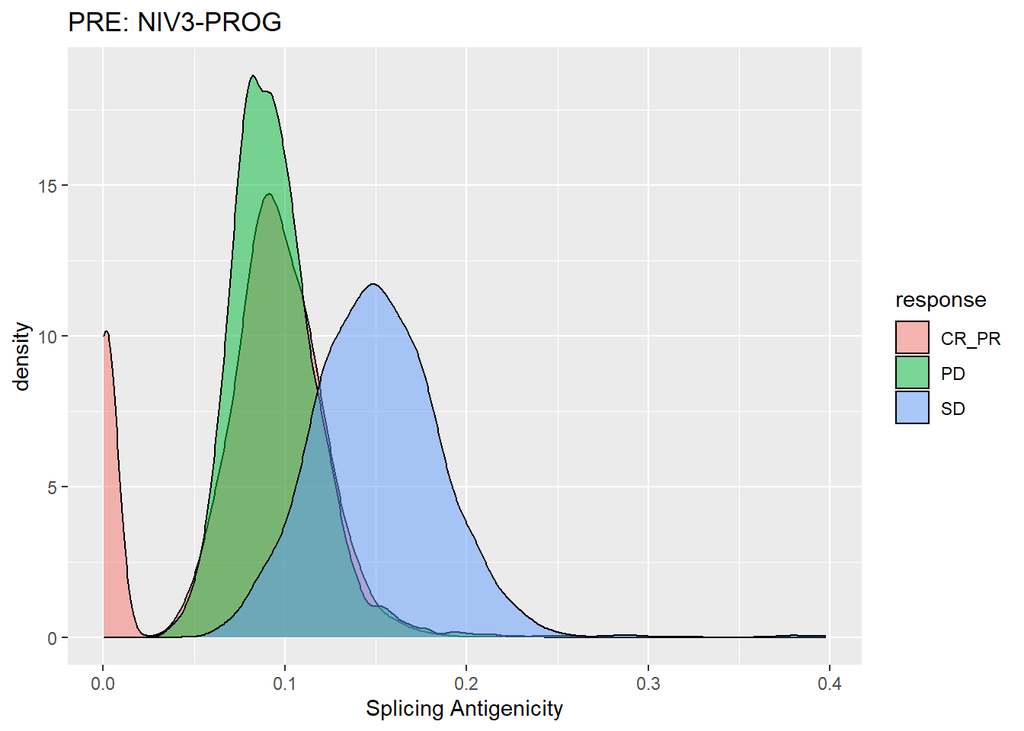

```r
responses<-c("CR_PR","SD","PD")
col_data_PRE <- col_data %>% dplyr::filter(time == "PRE" & response != "NE")

response_summ_PRE_list <- list()
for (i in seq(length(unique(col_data_PRE$treatment)))){
  treat<-unique(col_data_PRE$treatment)[i]
  response_summ_PRE <- data.frame(rownames(comp_vals_all))
  colnames(response_summ_PRE) <- "genes"
  rownames(response_summ_PRE) <- response_summ_PRE$genes
  col_data_PRE_small <- col_data_PRE %>% dplyr::filter(treatment == treat)
  for (resp in responses){
    samps <- col_data_PRE_small$samples[col_data_PRE_small$response==resp]
    if (length(samps)==0){
      response_summ_PRE[,resp] <- NA
    } else {
      comparisons <- col_data_PRE_small$comparisons[col_data_PRE_small$response==resp]
      genes_small <- unique(unlist(lapply(comparisons,function(comp){comp_genes[[comp]]})))
      response_summ_PRE[,resp] <- NA
      response_summ_PRE[genes_small,resp] <-apply(comp_vals_all[genes_small,samps],1,mean,na.rm=T)
    }
  }
  response_summ_PRE<-response_summ_PRE[,seq(2,ncol(response_summ_PRE))]
  resp_summ_nrow <- nrow(response_summ_PRE)
  response_summ_PRE_linear <- data.frame(c(response_summ_PRE$SD,response_summ_PRE$CR_PR,response_summ_PRE$PD),
                                     c(rep("SD",resp_summ_nrow),
                                       rep("CR_PR",resp_summ_nrow),
                                       rep("PD",resp_summ_nrow)))
  colnames(response_summ_PRE_linear) <- c("gene_metric","response")
  response_summ_PRE_linear <- response_summ_PRE_linear[complete.cases(response_summ_PRE_linear),]
  response_summ_PRE_linear$time <- "PRE"
  response_summ_PRE_linear$treat <- treat

    print(ggplot(response_summ_PRE_linear,aes(x=gene_metric,group=response,fill=response))+
            geom_density(alpha=0.5)+labs(title=sprintf("PRE: %s",treat))+xlab("Splicing Antigenicity"))

  if (i==1){
    response_summ_PRE_all_linear <- response_summ_PRE_linear
  } else {
    response_summ_PRE_all_linear <- rbind(response_summ_PRE_all_linear,response_summ_PRE_linear)
  }

  my_comparisons <- list(c("CR_PR","PD"),
                        c("CR_PR","SD"),
                        c("PD","SD"))
  if (i==1){
    wilcox_test_val_PRE <- compare_means(gene_metric ~ response,
                             comparisons = my_comparisons, p.adjust.method = "BH", data=response_summ_PRE_linear)
    wilcox_test_val_PRE$treat <- treat
    wilcox_test_val_PRE$group1_mean <- vapply(wilcox_test_val_PRE$group1,function(resp){
      mean(response_summ_PRE_linear$gene_metric[response_summ_PRE_linear$response==resp],na.rm=T)
    },numeric(1))
    wilcox_test_val_PRE$group2_mean <- vapply(wilcox_test_val_PRE$group2,function(resp){
      mean(response_summ_PRE_linear$gene_metric[response_summ_PRE_linear$response==resp],na.rm=T)
    },numeric(1))
    wilcox_test_val_PRE_all <- wilcox_test_val_PRE
  } else {
    wilcox_test_val_PRE <- compare_means(gene_metric ~ response,
                         comparisons = my_comparisons, p.adjust.method = "BH", data=response_summ_PRE_linear)
    wilcox_test_val_PRE$treat <- treat
    wilcox_test_val_PRE$group1_mean <- vapply(wilcox_test_val_PRE$group1,function(resp){
      mean(response_summ_PRE_linear$gene_metric[response_summ_PRE_linear$response==resp],na.rm=T)
    },numeric(1))
    wilcox_test_val_PRE$group2_mean <- vapply(wilcox_test_val_PRE$group2,function(resp){
      mean(response_summ_PRE_linear$gene_metric[response_summ_PRE_linear$response==resp],na.rm=T)
    },numeric(1))
    wilcox_test_val_PRE_all <- rbind(wilcox_test_val_PRE_all,wilcox_test_val_PRE)
  }
  # wilcox_test_val$y.position <- c(max(response_summ_PRE_linear$gene_metric)+(max(response_summ_PRE_linear$gene_metric)/4),
  #                                 max(response_summ_PRE_linear$gene_metric)+(max(response_summ_PRE_linear$gene_metric)/6),
  #                                 max(response_summ_PRE_linear$gene_metric)+(max(response_summ_PRE_linear$gene_metric)/8))
  # print(ggplot(response_summ_PRE_linear,aes(y=gene_metric,x=response))+
  #         geom_boxplot()+
  #         labs(title=sprintf("%s: %s",treat,"PRE"))+
  #         stat_pvalue_manual(wilcox_test_val,
  #                            label="p.adj"))
  # print(ggplot(response_summ_PRE_linear,aes(y=log10(gene_metric+1),x=response,fill=response))+
  #   geom_violin()+
  #   labs(title="PRE")+
  #   stat_compare_means(comparisons = my_comparisons,method = "wilcox.test"))
  #
  # print(ggplot(response_summ_PRE_linear,aes(x=log10(gene_metric+1),fill=response))+
  #   geom_density(alpha=0.4)+
  #   labs(title="PRE"))
}
```

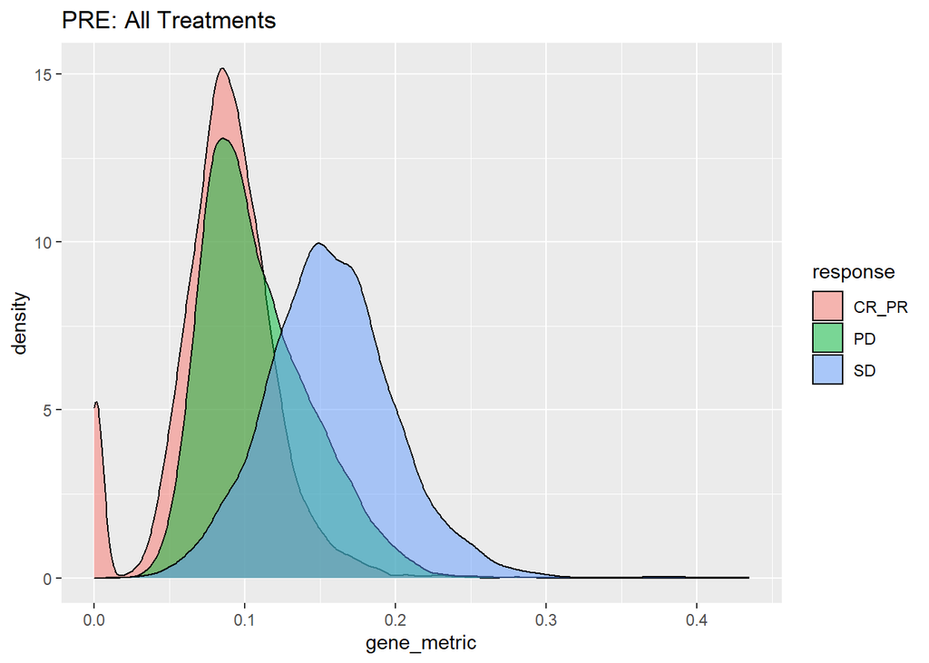

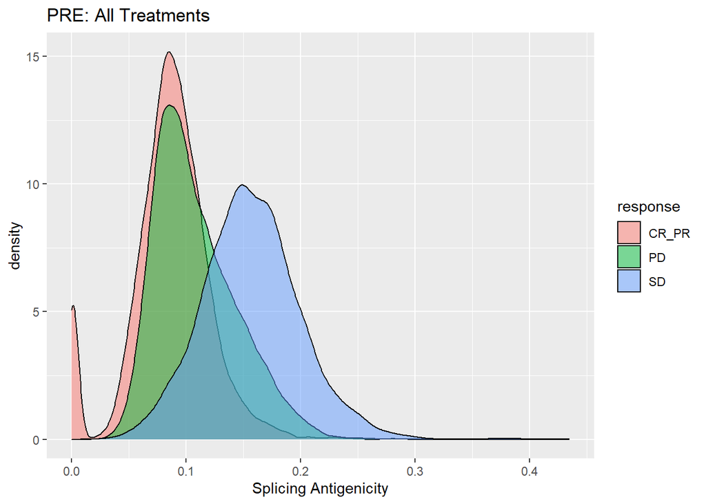

```r
wilcox_test_val_PRE_all$G1_ov_G2 <- wilcox_test_val_PRE_all$group1_mean/wilcox_test_val_PRE_all$group2_mean
wilcox_test_val_PRE_all$time <- "PRE"

print(ggplot(response_summ_PRE_all_linear,aes(x=gene_metric,group=response,fill=response))+
        geom_density(alpha=0.5)+labs(title="PRE: All Treatments"))+xlab("Splicing Antigenicity")
```

### Post average mean comparisons

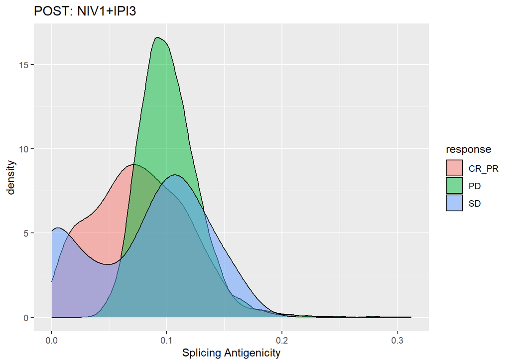

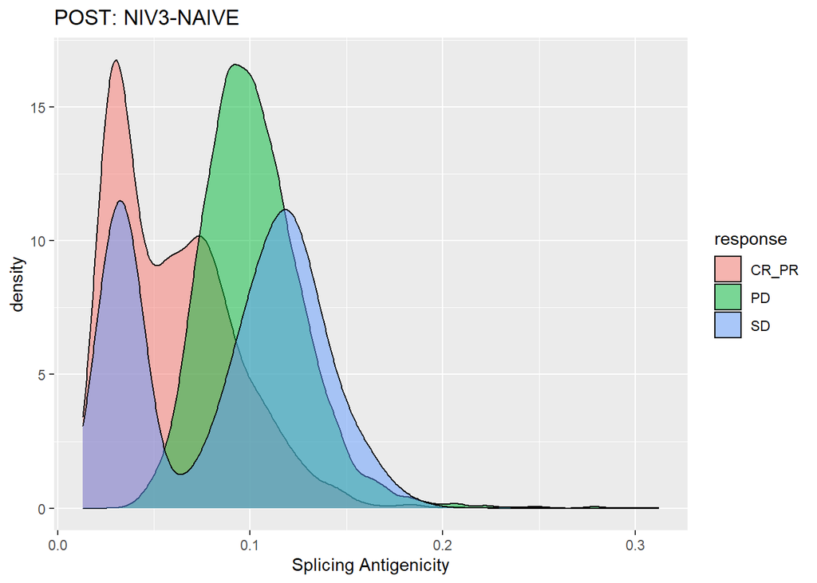

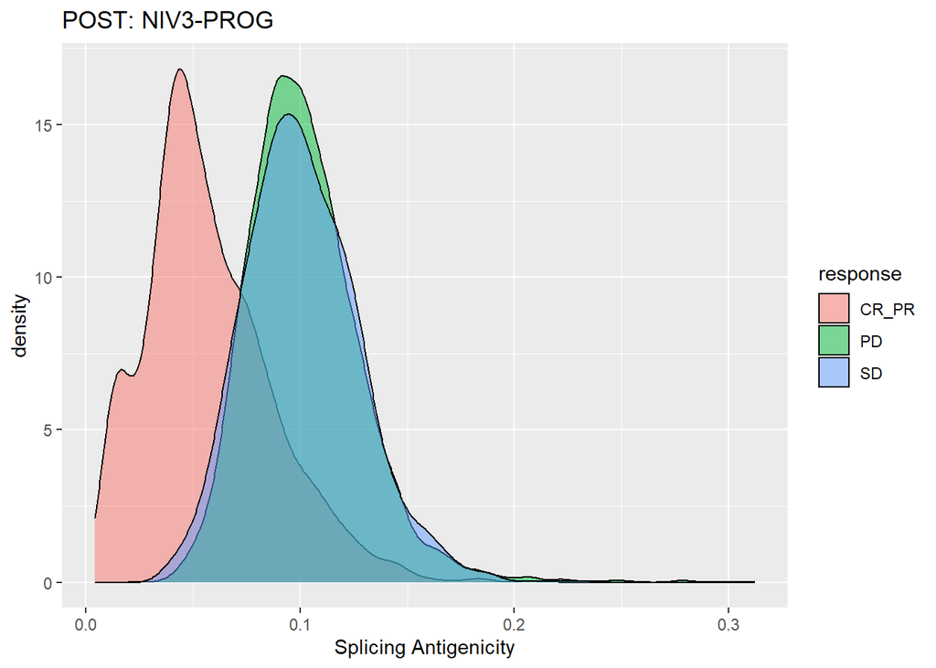

```r
responses<-c("CR_PR","SD","PD")
col_data_POST <- col_data %>% dplyr::filter(time == "POST" & response != "NE")

response_summ_POST_list <- list()
for (i in seq(length(unique(col_data_POST$treatment)))){
  treat<-unique(col_data_POST$treatment)[i]
  response_summ_POST <- data.frame(rownames(comp_vals_all))
  colnames(response_summ_POST) <- "genes"
  rownames(response_summ_POST) <- response_summ_POST$genes
  col_data_POST_small <- col_data_POST %>% dplyr::filter(treatment == treat)
  for (resp in responses){
    samps <- col_data_POST$samples[col_data_POST$response==resp]
    if (length(samps)==0){
      response_summ_POST[,resp] <- NA
    } else {
      comparisons <- col_data_POST_small$comparisons[col_data_POST_small$response==resp]
      genes_small <- unique(unlist(lapply(comparisons,function(comp){comp_genes[[comp]]})))
      response_summ_POST[,resp] <- NA
      response_summ_POST[genes_small,resp] <- apply(comp_vals_all[genes_small,samps],1,mean,na.rm=T)
      response_summ_POST$treat <- treat
    }
  }
  response_summ_POST<-response_summ_POST[,seq(2,ncol(response_summ_POST))]
  resp_summ_nrow <- nrow(response_summ_POST)
  response_summ_POST_linear <- data.frame(c(response_summ_POST$SD,response_summ_POST$CR_PR,response_summ_POST$PD),
                                     c(rep("SD",resp_summ_nrow),
                                       rep("CR_PR",resp_summ_nrow),
                                       rep("PD",resp_summ_nrow)))
  colnames(response_summ_POST_linear) <- c("gene_metric","response")
  response_summ_POST_linear <- response_summ_POST_linear[complete.cases(response_summ_POST_linear),]
  response_summ_POST_linear$time <- "POST"
  response_summ_POST_linear$treat <- treat

  print(ggplot(response_summ_POST_linear,aes(x=gene_metric,group=response,fill=response))+
        geom_density(alpha=0.5)+labs(title=sprintf("POST: %s",treat))+xlab("Splicing Antigenicity"))

  if (i==1){
    response_summ_POST_all_linear <- response_summ_POST_linear
  } else {
    response_summ_POST_all_linear <- rbind(response_summ_POST_all_linear,response_summ_POST_linear)
  }

  my_comparisons <- list(c("CR_PR","PD"),
                        c("CR_PR","SD"),
                        c("PD","SD"))
    if (i==1){
    wilcox_test_val_POST <- compare_means(gene_metric ~ response,
                             comparisons = my_comparisons, p.adjust.method = "BH", data=response_summ_POST_linear)
    wilcox_test_val_POST$treat <- treat
    wilcox_test_val_POST$group1_mean <- vapply(wilcox_test_val_POST$group1,function(resp){
      mean(response_summ_POST_linear$gene_metric[response_summ_POST_linear$response==resp],na.rm=T)
    },numeric(1))
    wilcox_test_val_POST$group2_mean <- vapply(wilcox_test_val_POST$group2,function(resp){
      mean(response_summ_POST_linear$gene_metric[response_summ_POST_linear$response==resp],na.rm=T)
    },numeric(1))
    wilcox_test_val_POST_all <- wilcox_test_val_POST
  } else {
    wilcox_test_val_POST <- compare_means(gene_metric ~ response,
                         comparisons = my_comparisons, p.adjust.method = "BH", data=response_summ_POST_linear)
    wilcox_test_val_POST$treat <- treat
    wilcox_test_val_POST$group1_mean <- vapply(wilcox_test_val_POST$group1,function(resp){
      mean(response_summ_POST_linear$gene_metric[response_summ_POST_linear$response==resp],na.rm=T)
    },numeric(1))
    wilcox_test_val_POST$group2_mean <- vapply(wilcox_test_val_POST$group2,function(resp){
      mean(response_summ_POST_linear$gene_metric[response_summ_POST_linear$response==resp],na.rm=T)
    },numeric(1))
    wilcox_test_val_POST_all <- rbind(wilcox_test_val_POST_all,wilcox_test_val_POST)
  }

  # wilcox_test_val$y.position <- c(max(response_summ_POST_linear$gene_metric)+(max(response_summ_POST_linear$gene_metric)/4),
  #                                 max(response_summ_POST_linear$gene_metric)+(max(response_summ_POST_linear$gene_metric)/6),
  #                                 max(response_summ_POST_linear$gene_metric)+(max(response_summ_POST_linear$gene_metric)/8))
  # print(ggplot(response_summ_POST_linear,aes(y=gene_metric,x=response))+
  #   geom_boxplot(aes(fill=response))+
  #   labs(title=sprintf("%s: %s",treat,"POST"))+
  #     stat_pvalue_manual(wilcox_test_val,label="p.adj"))

  # ggplot(response_summ_POST_linear,aes(y=log10(gene_metric+1),x=response,fill=response))+
  #   geom_violin()+
  #   labs(title="POST")+
  #   stat_compare_means(comparisons = my_comparisons,method = "wilcox.test")
  #
  # ggplot(response_summ_POST_linear,aes(x=log10(gene_metric+1),fill=response))+
  #   geom_density(alpha=0.4)+
  #   labs(title="POST")
}
```

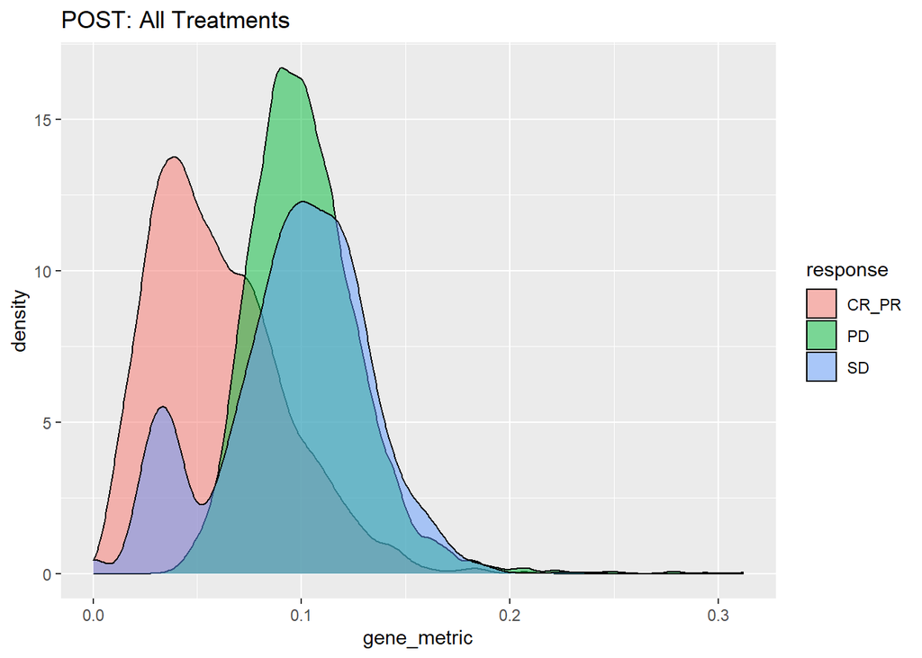

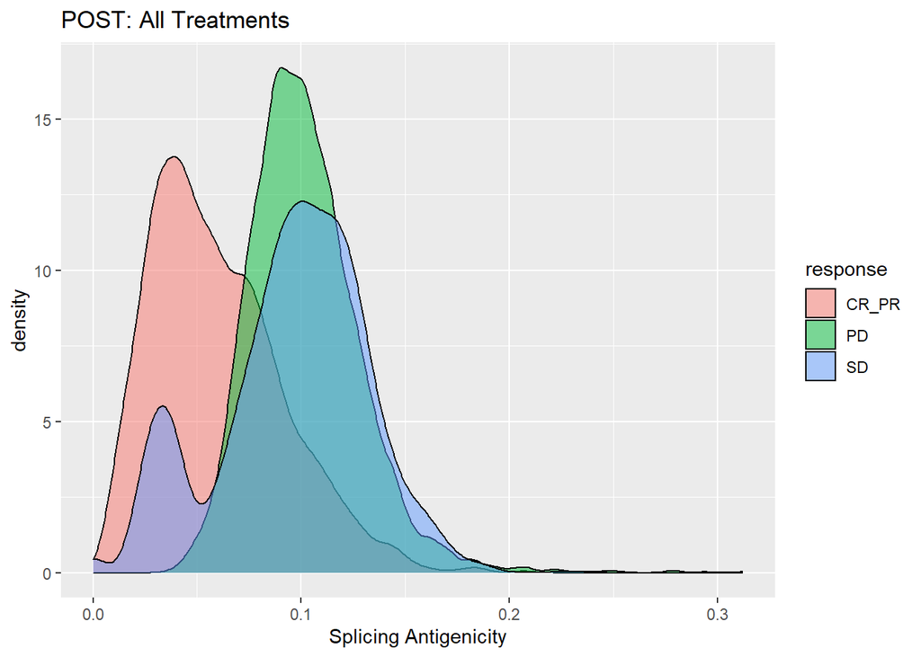

```r
wilcox_test_val_POST_all$G1_ov_G2 <- wilcox_test_val_POST_all$group1_mean/wilcox_test_val_POST_all$group2_mean
wilcox_test_val_POST_all$time <- "POST"


print(ggplot(response_summ_POST_all_linear,aes(x=gene_metric,group=response,fill=response))+
        geom_density(alpha=0.5)+labs(title="POST: All Treatments"))+xlab("Splicing Antigenicity")
```